# Multi-trait selection of promising quinoa (Chenopodium quinoa Willd.) accessions in an Andean valley of Ayacucho, Peru

# 1 Project Setup

```r
# pak::pak("reyzaguirre/st4gi")
library(st4gi)
library(factoextra)
library(vegan)
library(writexl)
library(cluster)
library(pvclust)
library(plotly)
library(corrplot)
library(htmlwidgets)
source('https://inkaverse.com/setup.r')
```

# 2 Data import

```r
gs <- "https://docs.google.com/spreadsheets/d/14QZQZCEdy0XHK6dqiWQOjy-tU769x_KRhZ-7OyU9phw/edit?gid=1912323931#gid=1912323931" %>%
  as_sheets_id()

date <- gs %>%
  range_read(ss = .,sheet = "fb")
```

```r
 info <- gs %>%
  range_read(ss = .,sheet ="dictionary")

info <- info |>
  dplyr::mutate(valor = vapply(valor,
                               \(x) if (length(x) == 0) NA_character_ else as.character(x[1]),
                               character(1)))

dic <- info |>
  dplyr::filter(tipo == "cualitativo", !is.na(valor),
                !is.na(categoria_en), categoria_en != "")


# date fb

fb <- date


for (cod in unique(dic$codigo)) {
  d  <- dic |> dplyr::filter(codigo == cod)
  lk <- setNames(d$categoria_en, d$valor)
  fb[[cod]] <- dplyr::coalesce(unname(lk[fb[[cod]]]), fb[[cod]])
}

mapa <- info |>
  dplyr::distinct(codigo, Acronym) |>
  dplyr::filter(codigo %in% names(fb))

fb <- fb |>
  dplyr::rename(dplyr::any_of(setNames(mapa$codigo, mapa$Acronym)))

fb %>% web_table(scrolly = "400px")
```

| Plot | Block | Sub-block | rows | cols | Trat | Ac- | PLD | GT | GH | SMS | MSC | PPA | PST | STC | LOD | PHS | PB | NPB | PPB | LS | LM | NLT | PTL | MLL | MLW | PC | LLC | LGC | MST | … |
| --- | --- | --- | --- | --- | --- | --- | --- | --- | --- | --- | --- | --- | --- | --- | --- | --- | --- | --- | --- | --- | --- | --- | --- | --- | --- | --- | --- | --- | --- | --- |
| 101 | I | SB1 | 1 | 1 | T1 | Ac-1 | Sparse | Herbaceous | Branched to the second third | Angular | Purple | Present | Present | Green | 2 | MF | Absent | 15.8 | Emerge obliquely from main stem | Rhomboid | Toothed | 16.4 | 4.57 | 6.72 | 6.03 | Green | Green-Red (striated/variegated) | Absent | Absent (stigma overgrowth) | … |
| 102 | I | SB1 | 1 | 2 | T13 | Ac-27 | Intermediate | Herbaceous | Simple | Angular | White | Present | Present | Green | 10 | MF | Absent | 9.4 | Emerge obliquely from main stem | Triangular | Serrated | 18.3 | 4.55 | 6.92 | 7.13 | Green | Green | Absent | Absent (stigma overgrowth) | … |
| 103 | I | SB1 | 1 | 3 | T25 | Ac-48 | Intermediate | Herbaceous | Simple | Cylindrical | Yellow | Not determined | Present | Green | 2 | MF | Absent | 7.9 | Emerge obliquely from main stem | Triangular | Serrated | 16.9 | 5.86 | 8.54 | 9.01 | Green-Red (striated/variegated) | Green-Red (striated/variegated) | Purple | Absent (stigma overgrowth) | … |
| 104 | I | SB1 | 1 | 4 | T37 | Ac-78 | High | Herbaceous | Simple | Angular | Yellow | Not determined | Present | Purple | 8 | MF | Absent | 7.9 | Emerge obliquely from main stem | Rhomboid | Serrated | 16.8 | 4.62 | 7.78 | 7.09 | Green-Red (striated/variegated) | Green-Red (striated/variegated) | Absent | Absent (stigma overgrowth) | … |
| 105 | I | SB1 | 1 | 5 | T49 | Ac-133 | Sparse | Herbaceous | Simple | Cylindrical | Yellow | Present | Present | Green | 2 | MF | Absent | 16.5 | Emerge obliquely from main stem | Triangular | Serrated | 19.7 | 4.17 | 5.94 | 6.1 | Green | Green | Absent | Absent (stigma overgrowth) | … |
| 106 | I | SB1 | 1 | 6 | T61 | Ac-153 | High | Herbaceous | Simple | Cylindrical | Purple | Not determined | Present | Red | 2 | MF | Absent | 7.9 | Emerge obliquely from main stem | Rhomboid | Serrated | 12.8 | 3.92 | 6.42 | 6.23 | Red | Green-Red (striated/variegated) | Purple | Absent (stigma overgrowth) | … |
| 107 | I | SB1 | 1 | 7 | T73 | Ac-166 | Sparse | Herbaceous | Simple | Angular | Purple | Present | Present | Purple | 48 | MF | Absent | 9 | Emerge obliquely from main stem | Rhomboid | Serrated | 7.3 | 2.75 | 4.78 | 4.66 | Green | Green | Purple | Present (anthers absent) | … |
| 108 | I | SB1 | 1 | 8 | T85 | Ac-210 | Sparse | Herbaceous | Branched to the second third | Cylindrical | Pink | Absent | Present | Green | 5 | MF | Absent | 9.1 | Emerge obliquely from main stem | Triangular | Toothed | 9.3 | 3.07 | 4.46 | 4.23 | Green | Green | White | Present (anthers absent) | … |
| 109 | I | SB1 | 1 | 9 | T97 | Ac-225 | Intermediate | Herbaceous | Simple | Cylindrical | Yellow | Present | Present | Purple | 30 | MF | Absent | 13.2 | Emerge obliquely from main stem | Triangular | Toothed | 18.3 | 3.38 | 4.71 | 4.42 | Green | Green | White | Present (anthers absent) | … |
| 110 | I | SB1 | 1 | 10 | T109 | Ac-241 | High | Herbaceous | Simple | Angular | Yellow | Present | Present | Green | 25.1 | MF | Absent | 10.5 | Emerge obliquely from main stem | Triangular | Toothed | 6.1 | 2.45 | 4.57 | 3.81 | Green | Green | White | Present (anthers absent) | … |

[output cut: 278 more lines]

# 3 Objective 1: To assess the phenotypic diversity of 144 quinoa accessions (Chenopodium quinoa Willd.) under the agroecological conditions of Ayacucho, Peru, using diversity indices and repeatability estimates of qualitative traits.

## 3.1 Morphological diversity based on qualitative descriptors

Na = number of accessions per class; Nc = observed classes; Ne = effective number of classes; He = Nei’s diversity index; H′ = Shannon–Weaver index.

```r
#  detector incoherence
dif <- fb |>
  dplyr::rename(block = Block, geno = Trat) |>
  dplyr::select(geno, block, PLD:GS, -dplyr::all_of(c("LOD", "NPB", "NLT", "PTL", "MLL", "MLW", "SYP", "PH", "SD", "PLr", "PDr", "GD", "TSW" ))) |>
  tidyr::pivot_longer(-c(geno, block), names_to = "variable", values_to = "valor") |>
  tidyr::pivot_wider(names_from = block, values_from = valor, names_prefix = "Rep_") |>
  dplyr::filter(Rep_I != Rep_II | is.na(Rep_I) != is.na(Rep_II))

# categorical accessions
quali <- fb |>
  dplyr::rename(block = Block, sub_block = `Sub-block`, Ac = `Ac-`, geno = Trat) |>
  dplyr::select(-dplyr::all_of(c("LOD", "NPB", "NLT", "PTL", "MLL", "MLW", "SYP", "PH", "SD", "PLr", "PDr", "GD", "TSW", "PHS"))) |>
  dplyr::arrange(geno, block) |>
  dplyr::distinct(geno, .keep_all = TRUE) |>
  dplyr::select(-Plot, -block, -sub_block, -rows, -cols, -Ac) |>
  dplyr::mutate(dplyr::across(-c(geno), as.factor))
```

```r
# 1. Diccionario: acrónimo
dic_q <- info |>
  dplyr::filter(tipo == "cualitativo", !is.na(categoria_en), categoria_en != "") |>
  dplyr::mutate(valor_num = suppressWarnings(as.numeric(valor)))

labs <- dic_q |>
  dplyr::distinct(Acronym, descripcion_en) |>
  tibble::deframe()

ord <- dic_q |>
  dplyr::distinct(Acronym, categoria_en, valor_num)

vars_q <- setdiff(names(quali), "geno")
stopifnot(nrow(quali) == 144, all(vars_q %in% names(labs)))

for (v in vars_q) {
  x   <- as.character(quali[[v]])
  bad <- setdiff(unique(x[!is.na(x)]), ord$categoria_en[ord$Acronym == v])
  if (length(bad)) {
    message("⚠ ", v, ": clases fuera del diccionario -> NA: ", paste(bad, collapse = ", "))
    quali[[v]][x %in% bad] <- NA
  }
}
quali <- quali |> dplyr::mutate(dplyr::across(dplyr::all_of(vars_q), droplevels))

# 3. Frecuencias por clase
sum_q <- function(df, v) {
  df |>
    dplyr::filter(!is.na(.data[[v]])) |>
    dplyr::count(cat_en = as.character(.data[[v]]), name = "Na") |>
    dplyr::mutate(fi = Na / sum(Na)) |>
    dplyr::left_join(
      ord |> dplyr::filter(Acronym == v) |> dplyr::select(cat_en = categoria_en, valor_num),
      by = "cat_en") |>
    dplyr::arrange(valor_num) |>
    dplyr::transmute(`Qualitative trait` = unname(labs[v]),
                     `Phenotypic classes observed` = cat_en, Na, fi)
}
qtb <- purrr::map_dfr(vars_q, \(v) sum_q(quali, v))

# 4. Índices Ne, He, H′ con bootstrap sobre accesiones (SE e IC 95 %)
div_counts <- function(cnt) {
  p <- cnt / sum(cnt); p <- p[p > 0]
  c(Ne = 1 / sum(p^2), He = 1 - sum(p^2), Hp = -sum(p * log(p)) + 0)
}

boot_div <- function(df, v, B = 2000) {
  d   <- df |> dplyr::filter(!is.na(.data[[v]])) |> droplevels()
  cnt <- unclass(table(as.character(d$geno), as.character(d[[v]])))
  est <- div_counts(colSums(cnt))
  bs  <- t(replicate(B, div_counts(
    colSums(cnt[sample.int(nrow(cnt), replace = TRUE), , drop = FALSE]))))
  se  <- apply(bs, 2, sd)
  ci  <- apply(bs, 2, quantile, probs = c(0.025, 0.975))
  tibble::tibble(
    n_acc = nrow(cnt), Nc = ncol(cnt), Ne = est[["Ne"]],
    He = est[["He"]], se_He = se[["He"]], He_lo = ci[1, "He"], He_hi = ci[2, "He"],
    Hp = est[["Hp"]], se_Hp = se[["Hp"]], Hp_lo = ci[1, "Hp"], Hp_hi = ci[2, "Hp"]
  )
}

set.seed(123)
div_tab <- purrr::map_dfr(vars_q, \(v) {
  boot_div(quali, v) |> dplyr::mutate(`Qualitative trait` = unname(labs[v]), .before = 1)
})

# 5. Tabla
fmt <- qtb |>
  dplyr::left_join(div_tab, by = "Qualitative trait") |>
  dplyr::group_by(`Qualitative trait`) |>
  dplyr::mutate(
    first = dplyr::row_number() == 1,
    Na    = as.character(Na),
    fi    = sprintf("%.2f", fi),
    Nc          = dplyr::if_else(first, as.character(Nc), ""),
    Ne          = dplyr::if_else(first, sprintf("%.2f", Ne), ""),
    `He ± SE`   = dplyr::if_else(first, sprintf("%.2f ± %.2f", He, se_He), ""),
    `He 95% CI` = dplyr::if_else(first, sprintf("%.2f–%.2f", He_lo, He_hi), ""),
    `H′ ± SE`   = dplyr::if_else(first, sprintf("%.2f ± %.2f", Hp, se_Hp), ""),
    `H′ 95% CI` = dplyr::if_else(first, sprintf("%.2f–%.2f", Hp_lo, Hp_hi), ""),
    `Qualitative trait` = dplyr::if_else(first, `Qualitative trait`, "")
  ) |>
  dplyr::ungroup() |>
  dplyr::select(`Qualitative trait`, `Phenotypic classes observed`, Na, fi,
                Nc, Ne, `He ± SE`, `He 95% CI`, `H′ ± SE`, `H′ 95% CI`)

se_  <- \(x) sd(x) / sqrt(length(x))
tq   <- stats::qt(0.975, df = nrow(div_tab) - 1)
ci_t <- \(x) sprintf("%.2f–%.2f", mean(x) - tq * se_(x), mean(x) + tq * se_(x))

mrow <- tibble::tibble(
  `Qualitative trait` = "Mean ± SE", `Phenotypic classes observed` = "", Na = "", fi = "",
  Nc          = sprintf("%.2f ± %.2f", mean(div_tab$Nc), se_(div_tab$Nc)),
  Ne          = sprintf("%.2f ± %.2f", mean(div_tab$Ne), se_(div_tab$Ne)),
  `He ± SE`   = sprintf("%.2f ± %.2f", mean(div_tab$He), se_(div_tab$He)),
  `He 95% CI` = ci_t(div_tab$He),
  `H′ ± SE`   = sprintf("%.2f ± %.2f", mean(div_tab$Hp), se_(div_tab$Hp)),
  `H′ 95% CI` = ci_t(div_tab$Hp)
)

Diversity <- dplyr::bind_rows(fmt, mrow)
Diversity |> web_table(scrolly = "400px")
```

| Qualitative trait | Phenotypic classes observed | Na | fi | Nc | Ne | He ± SE | He 95% CI | H′ ± SE | H′ 95% CI |
| --- | --- | --- | --- | --- | --- | --- | --- | --- | --- |
| Planting density | Sparse | 33 | 0.23 | 3 | 2.84 | 0.65 ± 0.01 | 0.61–0.66 | 1.07 ± 0.02 | 1.02–1.09 |
|  | Intermediate | 61 | 0.42 |  |  |  |  |  |  |
|  | High | 50 | 0.35 |  |  |  |  |  |  |
| Growth type | Herbaceous | 82 | 0.57 | 2 | 1.96 | 0.49 ± 0.01 | 0.46–0.50 | 0.68 ± 0.01 | 0.65–0.69 |
|  | Shrubby | 62 | 0.43 |  |  |  |  |  |  |
| Growth habit | Simple | 117 | 0.81 | 4 | 1.46 | 0.32 ± 0.05 | 0.22–0.40 | 0.60 ± 0.07 | 0.43–0.73 |
|  | Branched to the lower third | 5 | 0.03 |  |  |  |  |  |  |
|  | Branched to the second third | 21 | 0.15 |  |  |  |  |  |  |
|  | Branched with undefined main panicle | 1 | 0.01 |  |  |  |  |  |  |
| Main stem shape | Cylindrical | 80 | 0.56 | 2 | 1.98 | 0.49 ± 0.01 | 0.47–0.50 | 0.69 ± 0.01 | 0.66–0.69 |

[output cut: 105 more lines]

```r
writexl::write_xlsx(Diversity, "files/STable-1.xlsx")


# 5. Tabla 1

se_  <- \(x) sd(x) / sqrt(length(x))
tq   <- stats::qt(0.975, df = nrow(div_tab) - 1)
ci_t <- \(x) sprintf("%.2f–%.2f", mean(x) - tq * se_(x), mean(x) + tq * se_(x))

Diversity <- div_tab |>
  dplyr::transmute(
    `Qualitative trait`,
    Nc,
    Ne          = sprintf("%.2f", Ne),
    `He ± SE`   = sprintf("%.2f ± %.2f", He, se_He),
    `He 95% CI` = sprintf("%.2f–%.2f", He_lo, He_hi),
    `H′ ± SE`   = sprintf("%.2f ± %.2f", Hp, se_Hp),
    `H′ 95% CI` = sprintf("%.2f–%.2f", Hp_lo, Hp_hi)
  ) |>
  dplyr::mutate(Nc = as.character(Nc))

mrow <- tibble::tibble(
  `Qualitative trait` = "Mean ± SE",
  Nc          = sprintf("%.2f ± %.2f", mean(div_tab$Nc), se_(div_tab$Nc)),
  Ne          = sprintf("%.2f ± %.2f", mean(div_tab$Ne), se_(div_tab$Ne)),
  `He ± SE`   = sprintf("%.2f ± %.2f", mean(div_tab$He), se_(div_tab$He)),
  `He 95% CI` = ci_t(div_tab$He),
  `H′ ± SE`   = sprintf("%.2f ± %.2f", mean(div_tab$Hp), se_(div_tab$Hp)),
  `H′ 95% CI` = ci_t(div_tab$Hp)
)

Diversity <- dplyr::bind_rows(Diversity, mrow)


writexl::write_xlsx(Diversity, "files/Table-1.xlsx")
```

## 3.2 Morphological diversity based on quantitative descriptors

```r
quanti <- fb |> dplyr::rename(
    block     = Block,
    sub_block = `Sub-block`,
    Ac        = `Ac-`,
    geno      = Trat ) |> dplyr::select(
    1:Ac, LOD, NPB, NLT, PTL, MLL, MLW, SYP, PH, SD, PLr, PDr, GD, TSW ) |>
    dplyr::mutate(
    dplyr::across(1:Ac, as.factor),
    dplyr::across(-(1:Ac), as.numeric)
  )

exp <- quanti
```

```
Linear mixed model fit by REML ['lmerMod']
Formula: LOD ~ 1 + (1 | block) + (1 | sub_block) + (1 | geno)
   Data: dt.rm
Weights: weights

REML criterion at convergence: 2203.8

Scaled residuals:
    Min      1Q  Median      3Q     Max
-2.7181 -0.4051 -0.0910  0.2427  3.5600

Random effects:
 Groups    Name        Variance Std.Dev.
 geno      (Intercept) 113.949  10.6747
 sub_block (Intercept)   0.686   0.8282
 block     (Intercept)   4.347   2.0850
 Residual               53.425   7.3092
Number of obs: 288, groups:  geno, 144; sub_block, 12; block, 2

Fixed effects:
            Estimate Std. Error t value
(Intercept)   11.403      1.791   6.367
```

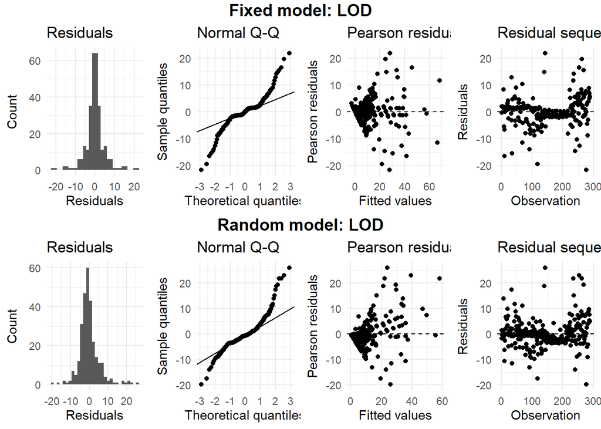

```
Linear mixed model fit by REML ['lmerMod']
Formula: NPB ~ 1 + (1 | block) + (1 | sub_block) + (1 | geno)
   Data: dt.rm
Weights: weights

REML criterion at convergence: 1684.8

Scaled residuals:
     Min       1Q   Median       3Q      Max
-2.14138 -0.45614 -0.00622  0.44660  2.47625

Random effects:
 Groups    Name        Variance Std.Dev.
 geno      (Intercept) 21.5869  4.6462
 sub_block (Intercept)  1.9332  1.3904
 block     (Intercept)  0.9192  0.9587
 Residual               7.4532  2.7301
Number of obs: 287, groups:  geno, 144; sub_block, 12; block, 2

Fixed effects:
            Estimate Std. Error t value
(Intercept)  13.6111     0.8926   15.25
```

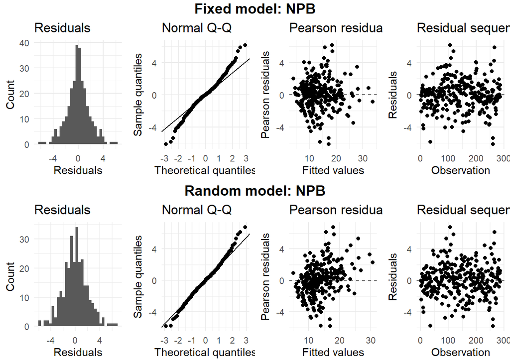

```
Linear mixed model fit by REML ['lmerMod']
Formula: NLT ~ 1 + (1 | block) + (1 | sub_block) + (1 | geno)
   Data: dt.rm
Weights: weights

REML criterion at convergence: 1320.3

Scaled residuals:
    Min      1Q  Median      3Q     Max
-7.3759 -0.0979 -0.0176  0.0909  7.4378

Random effects:
 Groups    Name        Variance  Std.Dev.
 geno      (Intercept) 24.754117 4.97535
 sub_block (Intercept)  0.011911 0.10914
 block     (Intercept)  0.008261 0.09089
 Residual               0.645854 0.80365
Number of obs: 288, groups:  geno, 144; sub_block, 12; block, 2

Fixed effects:
            Estimate Std. Error t value
(Intercept)   9.5602     0.4234   22.58
```

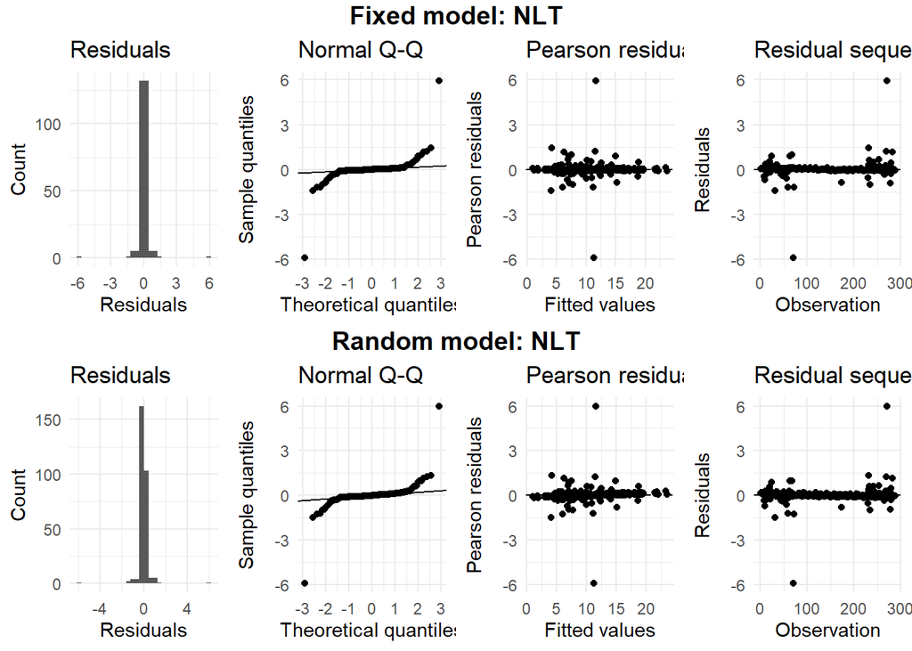

```
Linear mixed model fit by REML ['lmerMod']
Formula: PTL ~ 1 + (1 | block) + (1 | sub_block) + (1 | geno)
   Data: dt.rm
Weights: weights

REML criterion at convergence: 677.1

Scaled residuals:
    Min      1Q  Median      3Q     Max
-4.2171 -0.3276  0.0067  0.3440  4.2032

Random effects:
 Groups    Name        Variance Std.Dev.
 geno      (Intercept) 1.14514  1.0701
 sub_block (Intercept) 0.05543  0.2354
 block     (Intercept) 0.01462  0.1209
 Residual              0.13104  0.3620
Number of obs: 288, groups:  geno, 144; sub_block, 12; block, 2

Fixed effects:
            Estimate Std. Error t value
(Intercept)   4.2665     0.1426   29.92
```

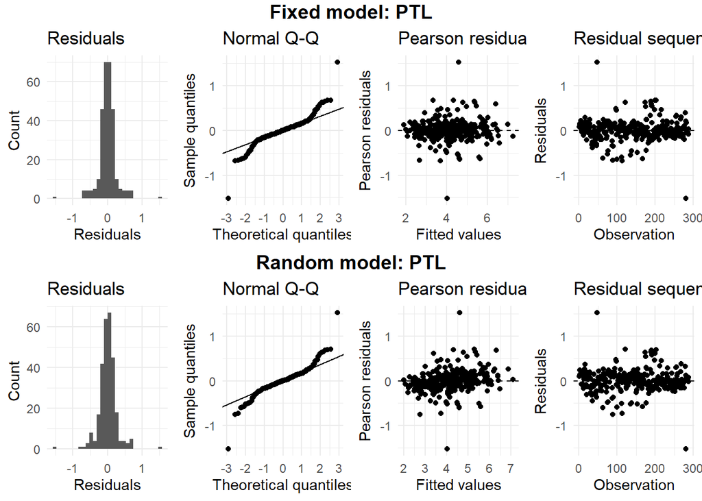

```
Linear mixed model fit by REML ['lmerMod']
Formula: MLL ~ 1 + (1 | block) + (1 | sub_block) + (1 | geno)
   Data: dt.rm
Weights: weights

REML criterion at convergence: 791.3

Scaled residuals:
    Min      1Q  Median      3Q     Max
-4.5928 -0.2474 -0.0413  0.2861  4.5289

Random effects:
 Groups    Name        Variance Std.Dev.
 geno      (Intercept) 1.789153 1.33759
 sub_block (Intercept) 0.007953 0.08918
 block     (Intercept) 0.012460 0.11163
 Residual              0.208331 0.45643
Number of obs: 288, groups:  geno, 144; sub_block, 12; block, 2

Fixed effects:
            Estimate Std. Error t value
(Intercept)   6.3234     0.1416   44.67
```

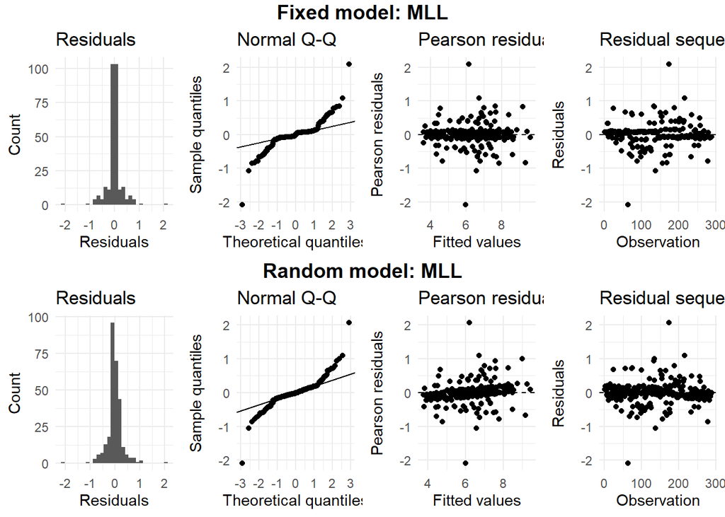

```
Linear mixed model fit by REML ['lmerMod']
Formula: MLW ~ 1 + (1 | block) + (1 | sub_block) + (1 | geno)
   Data: dt.rm
Weights: weights

REML criterion at convergence: 746.7

Scaled residuals:
     Min       1Q   Median       3Q      Max
-2.48027 -0.23972 -0.02762  0.25791  2.72562

Random effects:
 Groups    Name        Variance Std.Dev.
 geno      (Intercept) 2.549174 1.59661
 sub_block (Intercept) 0.010442 0.10219
 block     (Intercept) 0.007813 0.08839
 Residual              0.108051 0.32871
Number of obs: 288, groups:  geno, 144; sub_block, 12; block, 2

Fixed effects:
            Estimate Std. Error t value
(Intercept)   5.3662     0.1512    35.5
```

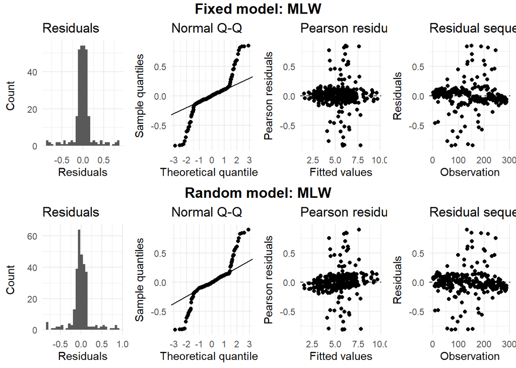

```
Linear mixed model fit by REML ['lmerMod']
Formula: SYP ~ 1 + (1 | block) + (1 | sub_block) + (1 | geno)
   Data: dt.rm
Weights: weights

REML criterion at convergence: 2590.1

Scaled residuals:
    Min      1Q  Median      3Q     Max
-3.4543 -0.3134 -0.1359  0.1782  4.9808

Random effects:
 Groups    Name        Variance Std.Dev.
 geno      (Intercept) 484.847  22.019
 sub_block (Intercept)   3.431   1.852
 block     (Intercept)   3.159   1.777
 Residual              191.975  13.856
Number of obs: 288, groups:  geno, 144; sub_block, 12; block, 2

Fixed effects:
            Estimate Std. Error t value
(Intercept)   26.333      2.429   10.84
```

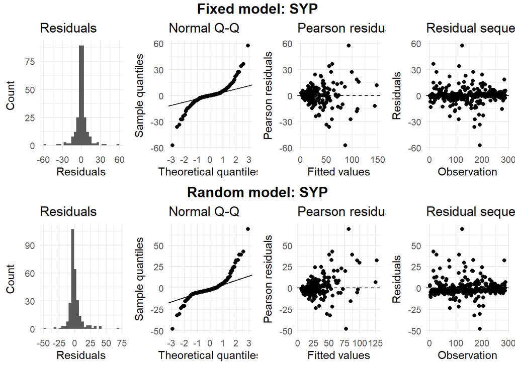

```
Linear mixed model fit by REML ['lmerMod']
Formula: PH ~ 1 + (1 | block) + (1 | sub_block) + (1 | geno)
   Data: dt.rm
Weights: weights

REML criterion at convergence: 2557.5

Scaled residuals:
     Min       1Q   Median       3Q      Max
-2.44155 -0.38868  0.00441  0.32029  2.66242

Random effects:
 Groups    Name        Variance Std.Dev.
 geno      (Intercept) 876.181  29.600
 sub_block (Intercept)   3.539   1.881
 block     (Intercept)   1.131   1.063
 Residual               95.500   9.772
Number of obs: 288, groups:  geno, 144; sub_block, 12; block, 2

Fixed effects:
            Estimate Std. Error t value
(Intercept)  124.692      2.697   46.23
```

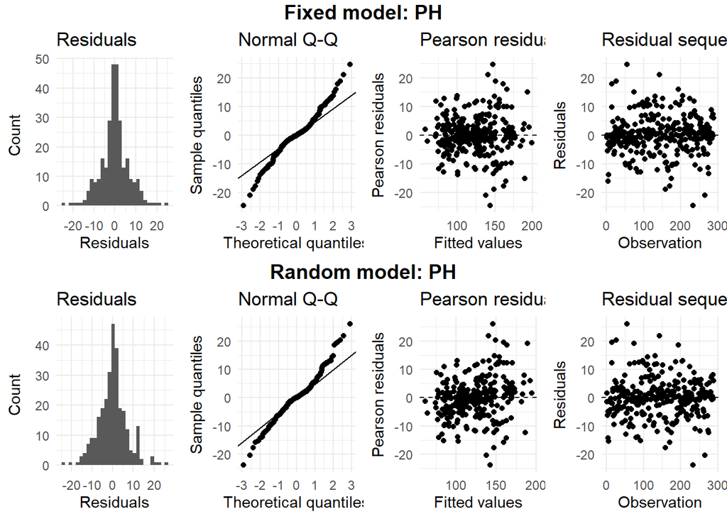

```
Linear mixed model fit by REML ['lmerMod']
Formula: SD ~ 1 + (1 | block) + (1 | sub_block) + (1 | geno)
   Data: dt.rm
Weights: weights

REML criterion at convergence: 1510.2

Scaled residuals:
    Min      1Q  Median      3Q     Max
-2.9122 -0.3296 -0.0493  0.2817  3.2514

Random effects:
 Groups    Name        Variance Std.Dev.
 geno      (Intercept) 19.43018 4.408
 sub_block (Intercept)  0.00000 0.000
 block     (Intercept)  0.04164 0.204
 Residual               2.93735 1.714
Number of obs: 288, groups:  geno, 144; sub_block, 12; block, 2

Fixed effects:
            Estimate Std. Error t value
(Intercept)  11.4242     0.4074   28.04
optimizer (nloptwrap) convergence code: 0 (OK)
boundary (singular) fit: see help('isSingular')
```

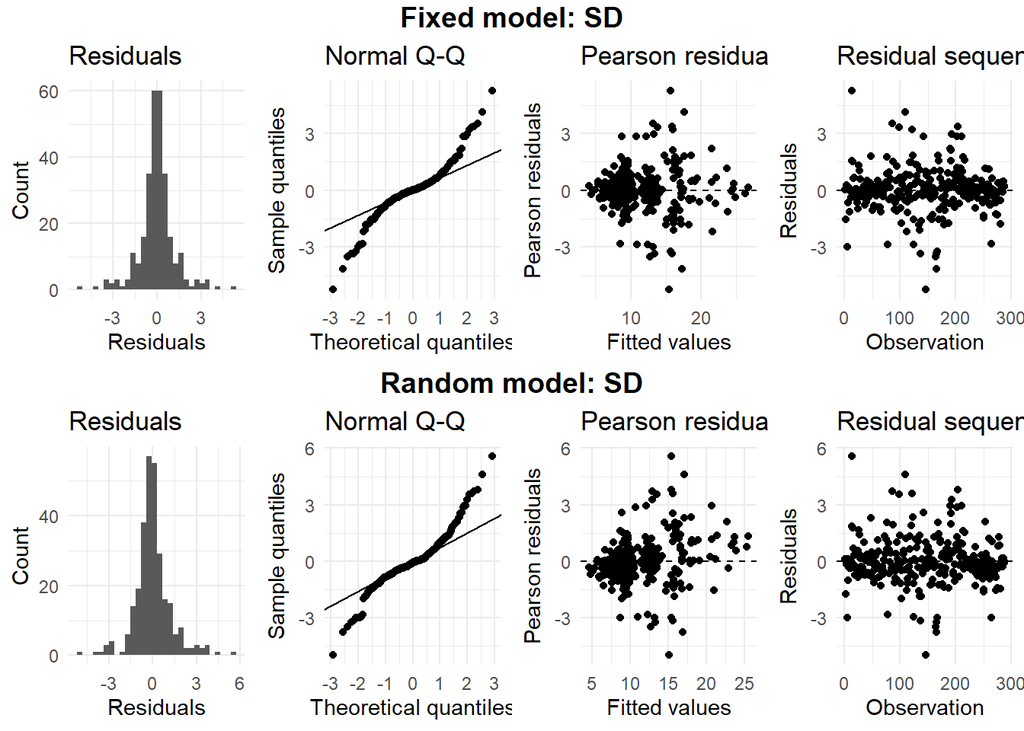

```
Linear mixed model fit by REML ['lmerMod']
Formula: PLr ~ 1 + (1 | block) + (1 | sub_block) + (1 | geno)
   Data: dt.rm
Weights: weights

REML criterion at convergence: 2150.1

Scaled residuals:
     Min       1Q   Median       3Q      Max
-2.15895 -0.42037 -0.08159  0.38645  2.92791

Random effects:
 Groups    Name        Variance Std.Dev.
 geno      (Intercept) 109.3858 10.4588
 sub_block (Intercept)   0.0000  0.0000
 block     (Intercept)   0.3656  0.6046
 Residual               40.8238  6.3893
Number of obs: 288, groups:  geno, 144; sub_block, 12; block, 2

Fixed effects:
            Estimate Std. Error t value
(Intercept)   41.689      1.041   40.04
optimizer (nloptwrap) convergence code: 0 (OK)
boundary (singular) fit: see help('isSingular')
```

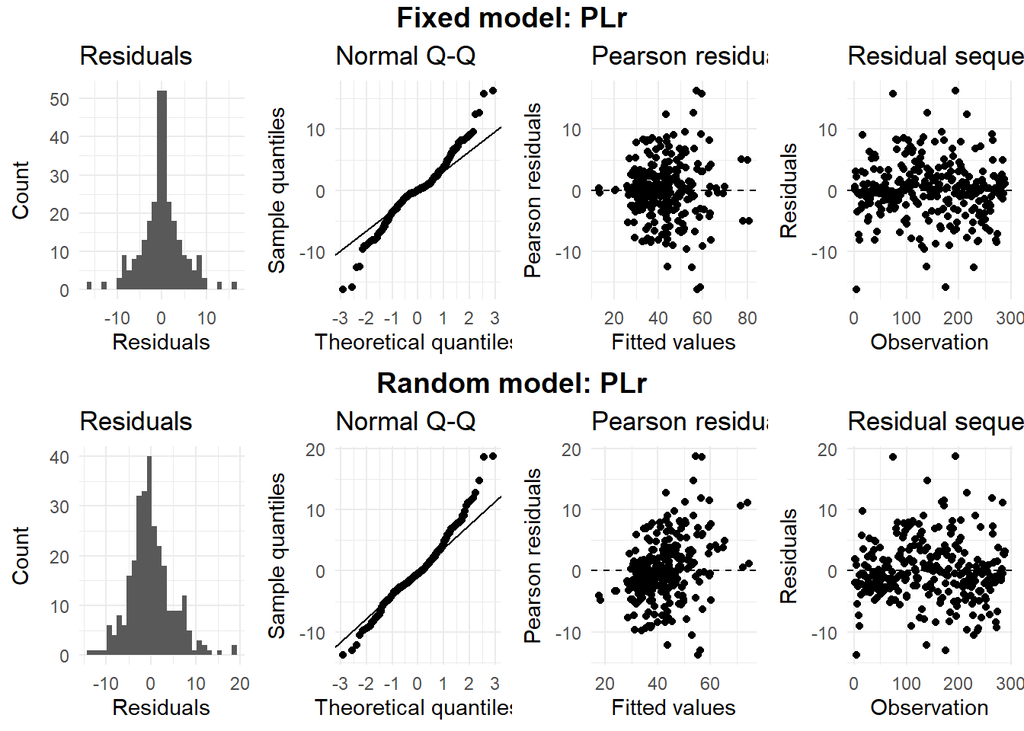

```
Linear mixed model fit by REML ['lmerMod']
Formula: PDr ~ 1 + (1 | block) + (1 | sub_block) + (1 | geno)
   Data: dt.rm
Weights: weights

REML criterion at convergence: 1727.3

Scaled residuals:
    Min      1Q  Median      3Q     Max
-2.5159 -0.3434 -0.0993  0.2781  3.6085

Random effects:
 Groups    Name        Variance Std.Dev.
 geno      (Intercept) 26.0428  5.1032
 sub_block (Intercept)  0.4111  0.6412
 block     (Intercept)  0.2472  0.4972
 Residual               8.7641  2.9604
Number of obs: 288, groups:  geno, 144; sub_block, 12; block, 2

Fixed effects:
            Estimate Std. Error t value
(Intercept)  10.6540     0.6076   17.54
```

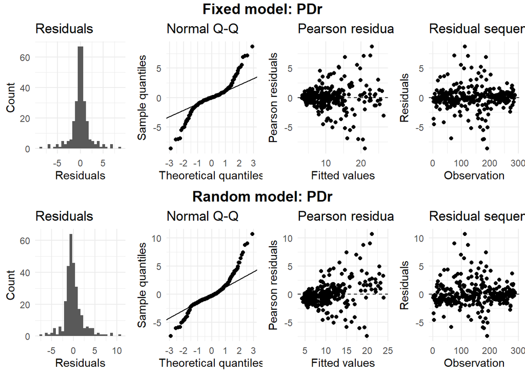

```
Linear mixed model fit by REML ['lmerMod']
Formula: GD ~ 1 + (1 | block) + (1 | sub_block) + (1 | geno)
   Data: dt.rm
Weights: weights

REML criterion at convergence: -554.4

Scaled residuals:
     Min       1Q   Median       3Q      Max
-2.65566 -0.32439 -0.03165  0.34688  2.48508

Random effects:
 Groups    Name        Variance   Std.Dev.
 geno      (Intercept) 0.01953933 0.139783
 sub_block (Intercept) 0.00005381 0.007336
 block     (Intercept) 0.00000000 0.000000
 Residual              0.00167342 0.040907
Number of obs: 288, groups:  geno, 144; sub_block, 12; block, 2

Fixed effects:
            Estimate Std. Error t value
(Intercept)  1.92729    0.01208   159.5
optimizer (nloptwrap) convergence code: 0 (OK)
boundary (singular) fit: see help('isSingular')
```

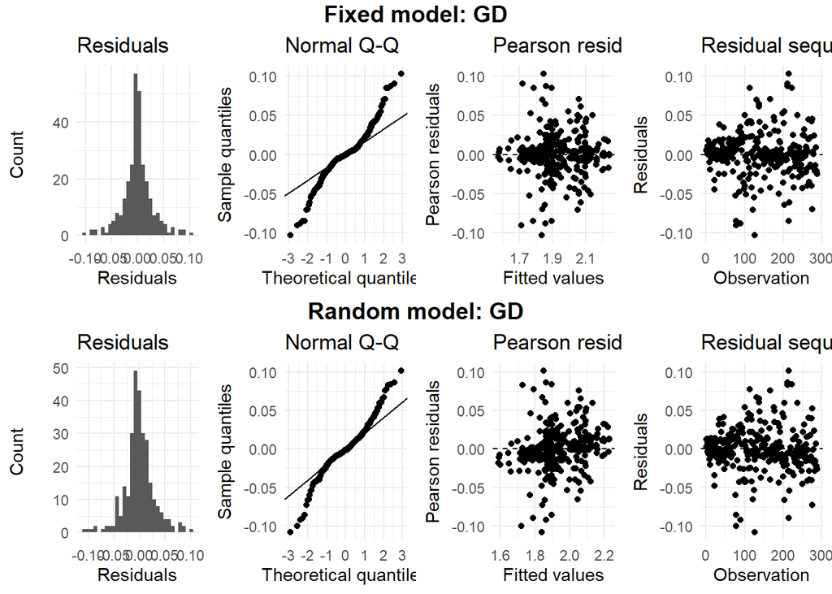

```
Linear mixed model fit by REML ['lmerMod']
Formula: TSW ~ 1 + (1 | block) + (1 | sub_block) + (1 | geno)
   Data: dt.rm
Weights: weights

REML criterion at convergence: 169.1

Scaled residuals:
    Min      1Q  Median      3Q     Max
-3.8688 -0.2723  0.0031  0.3239  3.8097

Random effects:
 Groups    Name        Variance   Std.Dev.
 geno      (Intercept) 0.32749399 0.572271
 sub_block (Intercept) 0.00127477 0.035704
 block     (Intercept) 0.00001348 0.003671
 Residual              0.01532523 0.123795
Number of obs: 288, groups:  geno, 144; sub_block, 12; block, 2

Fixed effects:
            Estimate Std. Error t value
(Intercept)   2.8077     0.0494   56.83
```

[1 more figures not shown]

```r
rslt <- 8:length(exp) %>% map(\(x) {

trait <- names(exp)[x]

exp %>%
   drop_na(trait)%>%
  H2cal(trait = trait
    , gen.name = "geno"
    , rep.n = 2
    , fixed.model = ~ 0 + (1|block) + (1|sub_block)  + geno
    , random.model = ~ 1 + (1|block) + (1|sub_block) + (1|geno)
    , summary = TRUE
    , emmeans = FALSE
    , plot_diag = TRUE
    , outliers.rm = FALSE
    )

})
```

```r
tabsmr <- 1:length(rslt) %>% map(\(x) {
      rslt[[x]][["tabsmr"]]
      }) %>%
  bind_rows()

blues <- 1:length(rslt) %>% map(\(x) {
      rslt[[x]][["blues"]] %>% dplyr::select(!matches("smith.w"))
      }) %>% Reduce(function(...) merge(..., all = TRUE
                                        , by = c('geno')), .)

blups <- 1:length(rslt) %>% map(\(x) {
      rslt[[x]][["blups"]] %>% dplyr::select(!matches("smith.w"))
      }) %>% Reduce(function(...) merge(..., all = TRUE
                                        , by = c('geno')), .)

tabsmr %>% web_table(scrolly = "400px")
```

| trait | rep | geno | env | year | mean | std | min | max | V.g | V.e | V.p | repeatability | H2.s | H2.p | H2.c |
| --- | --- | --- | --- | --- | --- | --- | --- | --- | --- | --- | --- | --- | --- | --- | --- |
| LOD | 2 | 144 | 1 | 1 | 11.4 | 11.95 | -1.35 | 68.37 | 113.95 | 53.42 | 140.66 | 0.81 | 0.81 | 0.89 | 0.8 |
| NPB | 2 | 144 | 1 | 1 | 13.61 | 5.06 | 4.68 | 32.66 | 21.59 | 7.45 | 25.31 | 0.85 | 0.85 | 0.9 | 0.84 |
| NLT | 2 | 144 | 1 | 1 | 9.56 | 5.01 | 1.09 | 23.64 | 24.75 | 0.65 | 25.08 | 0.99 | 0.99 | 0.99 | 0.99 |
| PTL | 2 | 144 | 1 | 1 | 4.27 | 1.1 | 2.03 | 7.04 | 1.15 | 0.13 | 1.21 | 0.95 | 0.95 | 0.97 | 0.94 |
| MLL | 2 | 144 | 1 | 1 | 6.32 | 1.38 | 3.66 | 9.5 | 1.79 | 0.21 | 1.89 | 0.94 | 0.94 | 0.97 | 0.94 |
| MLW | 2 | 144 | 1 | 1 | 5.37 | 1.62 | 1.59 | 9.68 | 2.55 | 0.11 | 2.6 | 0.98 | 0.98 | 0.99 | 0.98 |
| SYP | 2 | 144 | 1 | 1 | 26.33 | 24.24 | 2.85 | 146.94 | 484.85 | 191.98 | 580.83 | 0.83 | 0.83 | 0.91 | 0.83 |
| PH | 2 | 144 | 1 | 1 | 124.69 | 30.52 | 58.51 | 197.62 | 876.18 | 95.5 | 923.93 | 0.95 | 0.95 | 0.97 | 0.95 |
| SD | 2 | 144 | 1 | 1 | 11.42 | 4.59 | 4.2 | 26.56 | 19.43 | 2.94 | 20.9 | 0.93 | 0.93 | 0.96 | 0.93 |
| PLr | 2 | 144 | 1 | 1 | 41.69 | 11.39 | 13.45 | 80.45 | 109.39 | 40.82 | 129.8 | 0.84 | 0.84 | 0.91 | 0.84 |

[output cut: 3 more lines]

## 3.3 Tabla 2: Presents descriptive statistics for the quantitative traits evaluated in the blues dataset. For each trait, the table reports the mean, minimum, maximum, coefficient of variation (CV%) and broad-sense heritability (H²), providing a summary of the central tendency, range, relative variability and genetic determination of the measured characteristics.

```r
# info %>% dplyr::count(tipo)
# info %>% dplyr::filter(Acronym %in% c("LOD","NPB","NLT","PTL","MLL","MLW","SYP","PH","SD","PLr","PDr","GD","TSW")) %>%
#   dplyr::distinct(Acronym, tipo, descripcion_en)

passport_data <- gs %>%
  range_read(ss = .,sheet ="passport_data")

# machs en passport-----
blues <- blues %>%
  dplyr::left_join(
    passport_data %>% dplyr::select(Trat, CODIGO),
    by = c("geno" = "Trat")
  ) %>%
  dplyr::mutate(geno = CODIGO) %>%
  dplyr::select(-CODIGO)
#---------------------------

bluesmeans <- blues

bluesmeans %>%
  dplyr::select(c(2:14)) %>%
  dplyr::summarise(dplyr::across(dplyr::everything(), ~ sum(.x < 0, na.rm = TRUE))) %>%
  tidyr::pivot_longer(dplyr::everything(), names_to = "trait", values_to = "n_negative_BLUEs") %>%
  dplyr::filter(n_negative_BLUEs > 0)
```

```
# A tibble: 1 × 2
  trait n_negative_BLUEs
  <chr>            <int>
1 LOD                  6
```

```r
rl <- bluesmeans %>%
  dplyr::select(c(2:14)) %>%
  dplyr::mutate(dplyr::across(dplyr::everything(), ~ ifelse(.x < 0, 0, .x))) %>%
  dplyr::summarise(dplyr::across(
    dplyr::everything(),
    list(
      Mean    = ~ round(mean(.x, na.rm = TRUE), 2),
      Min     = ~ round(min(.x, na.rm = TRUE), 2),
      Max     = ~ round(max(.x, na.rm = TRUE), 2),
      `CV(%)` = ~ round(sd(.x, na.rm = TRUE) / mean(.x, na.rm = TRUE) * 100, 2)
    )
  )) %>%
  tidyr::pivot_longer(
    cols = dplyr::everything(),
    names_to = c("Quantitative trait", "stat"),
    names_pattern = "^(.*)_(Mean|Min|Max|CV\\(%\\))$",
    values_to = "value"
  ) %>%
  tidyr::pivot_wider(names_from = stat, values_from = value) %>%
  dplyr::mutate(dplyr::across(Mean:`CV(%)`, ~ formatC(.x, format = "f", digits = 2)))

stopifnot("repeatability" %in% names(tabsmr))

rep_tab <- tabsmr %>%
  dplyr::distinct(trait, .keep_all = TRUE) %>%
  dplyr::transmute(
    `Quantitative trait` = trait,
    Repeatability = sprintf("%.2f", repeatability)
  )

rl <- rl %>%
  dplyr::left_join(rep_tab, by = "Quantitative trait")

stopifnot(nrow(rl) == 13, !any(is.na(rl$Repeatability)))

labs_n <- info |>
  dplyr::filter(Acronym %in% rl$`Quantitative trait`, !is.na(descripcion_en)) |>
  dplyr::distinct(Acronym, descripcion_en) |>
  tibble::deframe()

faltan <- setdiff(rl$`Quantitative trait`, names(labs_n))
if (length(faltan)) stop("Sin descripcion_en en el diccionario para: ", paste(faltan, collapse = ", "))

rl <- rl |>
  dplyr::mutate(`Quantitative trait` = unname(labs_n[`Quantitative trait`]))

rl |> web_table()
```

| Quantitative trait | Mean | Min | Max | CV(%) | Repeatability |
| --- | --- | --- | --- | --- | --- |
| Percentage of lodged plants (%) | 11.43 | 0.00 | 68.37 | 104.26 | 0.81 |
| Number of primary branches | 13.61 | 4.68 | 32.66 | 37.19 | 0.85 |
| Number of leaf teeth | 9.56 | 1.09 | 23.64 | 52.40 | 0.99 |
| Petiole length (cm) | 4.27 | 2.03 | 7.04 | 25.86 | 0.95 |
| Maximum leaf length (cm) | 6.32 | 3.66 | 9.50 | 21.80 | 0.94 |
| Maximum leaf width (cm) | 5.37 | 1.59 | 9.68 | 30.12 | 0.98 |
| Seed yield per plant | 26.33 | 2.85 | 146.94 | 92.04 | 0.83 |
| Plant height | 124.69 | 58.51 | 197.62 | 24.48 | 0.95 |
| Stem diameter | 11.42 | 4.20 | 26.56 | 40.19 | 0.93 |
| Panicle length | 41.69 | 13.45 | 80.45 | 27.33 | 0.84 |

[output cut: 3 more lines]

```r
writexl::write_xlsx(rl, "files/Table-2.xlsx")
```

# 4 Objective 2: To identify promising accessions using BLUEs of four agronomic traits and to compare five selection approaches.

## 4.1 Data preparation

The BLUEs of four traits (SYP, TSW, PH, SD) were used for the 144 accessions. Traits were rescaled to 0–1 so that higher values are always better: SYP, TSW and SD are maximized, whereas PH is entered as a negative penalty: its distance to an optimal intermediate range (P25–P75) is computed and then inverted, so that intermediate heights are favoured. The top 10 % of accessions (n = 14) was retained by each method.

```r
vars4 <- c("SYP", "TSW", "PH", "SD")


dat <- blues |>
  dplyr::select(geno, dplyr::all_of(vars4))
stopifnot(nrow(dat) == 144, !anyNA(dat))


dat4  <- tibble::column_to_rownames(as.data.frame(dat), "geno")
n_top <- round(0.10 * nrow(dat))

w <- c(SYP = 3, TSW = 2, PH = 1, SD = 1)
w <- (w / sum(w))[vars4]

# PH penalty: distance to the optimal intermediate range (P25-P75); 0 inside the range
ph_rng <- quantile(dat$PH, c(0.25, 0.75))
ph_pen <- pmax(ph_rng[[1]] - dat$PH, 0) + pmax(dat$PH - ph_rng[[2]], 0)
mm <- \(x) (x - min(x)) / (max(x) - min(x))

# Direction: SYP, TSW, SD (+) | PH penalty (-)
M <- dat |>
  dplyr::mutate(PH = ph_pen, dplyr::across(-geno, mm),
                PH = 1 - PH) |>
  tibble::column_to_rownames("geno")

scores  <- tibble::tibble(geno = dat$geno)
methods <- c("PCA", "Elston", "Mulamba-Mock", "Ideotype", "RF")

top_df <- function(method) {
  scores |>
    dplyr::mutate(Rank = rank(-.data[[method]], ties.method = "min")) |>
    dplyr::arrange(Rank, geno) |>
    dplyr::slice_head(n = n_top) |>
    dplyr::select(Rank, Accession = geno, Score = dplyr::all_of(method)) |>
    dplyr::left_join(dat, by = c("Accession" = "geno")) |>
    dplyr::mutate(Score = signif(Score, 4),
                  dplyr::across(dplyr::all_of(vars4), \(x) round(x, 2)))
}

web_table <- function(x, caption = NULL) {
  DT::datatable(x, rownames = FALSE, caption = caption, filter = "top",
                extensions = "Buttons",
                options = list(pageLength = 14, scrollX = TRUE, dom = "Bfrtip",
                               buttons = c("copy", "csv", "excel")),
                class = "compact stripe hover")
}

plot_top <- function(method, title) {
  top_df(method) |>
    ggplot(aes(reorder(Accession, Score), Score)) +
    geom_col(fill = "#2166AC") +
    coord_flip() +
    labs(x = NULL, y = "Score", title = title) +
    theme_minimal()
}
```

## 4.2 Principal component analysis

PCA was run on the standardized BLUEs, with PH replaced by its penalty (distance to P25–P75) multiplied by −1, so that intermediate plant height is favoured. The first principal component, oriented so that SYP loads positively, was used as the selection score.

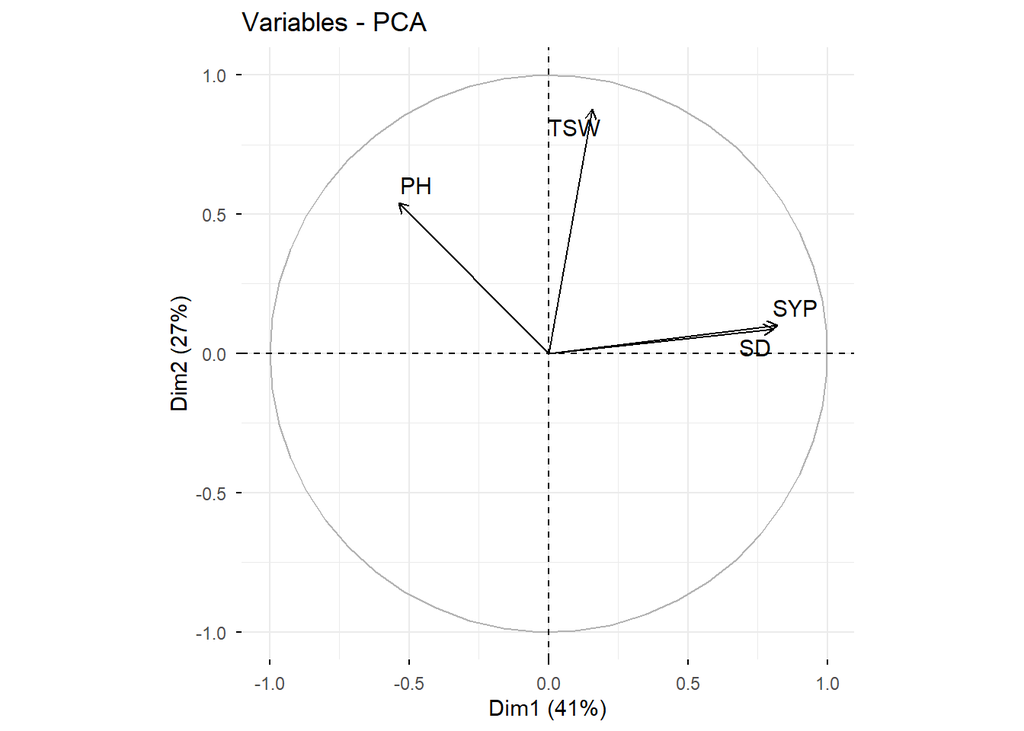

```r
dat4_o <- dat4
dat4_o$PH <- -ph_pen             # PH penalty negative: intermediate height is best

mv <- FactoMineR::PCA(dat4_o, scale.unit = TRUE, graph = FALSE)

scores$PCA <- as.numeric(mv$ind$coord[as.character(dat$geno), 1] *
                         sign(mv$var$coord["SYP", 1]))

factoextra::fviz_pca_var(mv, repel = TRUE)
```

```r
top_df("PCA") |> web_table(caption = "Top 10 % accessions by PCA (PC1 score)")
```

| Rank | Accession | Score | SYP | TSW | PH | SD |
| --- | --- | --- | --- | --- | --- | --- |
| 1 | UNSCHLGBVCHQ60405-61-2013 | 5.905 | 146.94 | 2.72 | 191.56 | 21.32 |
| 2 | UNSCHLGBVCHQ60405-56-2013 | 3.935 | 100 | 2.72 | 188.48 | 16.92 |
| 3 | UNSCHLGBVCHQ60405-57-2013 | 3.228 | 80.78 | 2.86 | 172.77 | 19.58 |
| 4 | UNSCHLGBVCHQ60405-281-2022 | 3.13 | 14.55 | 2.84 | 197.62 | 24.85 |
| 5 | UNSCHLGBVCHQ60405-32-2013 | 3.124 | 71.15 | 2.88 | 187.18 | 16.7 |
| 6 | UNSCHLGBVCHQ60405-25-2013 | 3.033 | 83.99 | 2.47 | 169.42 | 19.06 |
| 7 | UNSCHLGBVCHQ60405-125-2013 | 2.567 | 54.07 | 4.05 | 160.19 | 21.55 |
| 8 | UNSCHLGBVCHQ60405-282-2022 | 2.553 | 19.15 | 3.76 | 175.26 | 24.47 |
| 9 | UNSCHLGBVCHQ60405-72-2013 | 2.504 | 71.23 | 2.4 | 167.13 | 18.41 |
| 10 | UNSCHLGBVCHQ60405-293B-2022 | 2.489 | 18.46 | 2.96 | 171 | 26.56 |

[output cut: 4 more lines]

## 4.3 Elston index

The Elston (1963) index was computed with `st4gi::elston()`, as in the F7 selection stage of Lozano-Isla et al. (2023). It is a weight-free index on standardized trait means, so the trait to be minimized (the PH penalty) is multiplied by −1 before the calculation. The index is used here with the four traits: SYP, TSW and SD are maximized and the PH penalty is minimized.

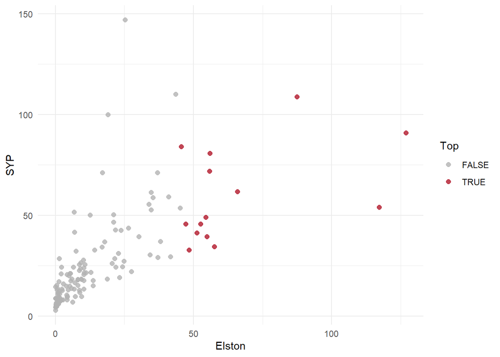

```r
elston_df <- data.frame(geno = as.character(dat$geno),
                        SYP = dat$SYP, TSW = dat$TSW, SD = dat$SD,
                        PH  = -ph_pen)          # PH penalty negative: intermediate height is best

elst <- tryCatch(
  st4gi::elston(traits = c("SYP", "TSW", "SD", "PH"), geno = "geno", dfr = elston_df),
  error = \(e) st4gi::elston(elston_df, vars = c("SYP", "TSW", "SD", "PH"), geno = "geno")
)

idx_col <- grep("index", names(elst), ignore.case = TRUE)[1]
scores$Elston <- elst[[idx_col]][match(as.character(dat$geno),
                                       as.character(elst$geno))]

sel <- top_df("Elston")$Accession
dplyr::mutate(dat, Elston = scores$Elston, Top = geno %in% sel) |>
  ggplot(aes(Elston, SYP, color = Top)) +
  geom_point(size = 2, alpha = .8) +
  scale_color_manual(values = c("grey70", "#B2182B")) +
  theme_minimal()
```

```r
top_df("Elston") |> web_table(caption = "Top 10 % accessions by Elston index")
```

| Rank | Accession | Score | SYP | TSW | PH | SD |
| --- | --- | --- | --- | --- | --- | --- |
| 1 | UNSCHLGBVCHQ60405-126-2013 | 126.8 | 90.81 | 3.14 | 141.07 | 16.9 |
| 2 | UNSCHLGBVCHQ60405-125-2013 | 117.2 | 54.07 | 4.05 | 160.19 | 21.55 |
| 3 | UNSCHLGBVCHQ60405-287-2022 | 87.36 | 108.87 | 2.87 | 148.86 | 13.14 |
| 4 | UNSCHLGBVCHQ60405-129-2013 | 65.84 | 61.8 | 2.94 | 150.23 | 16.03 |
| 5 | UNSCHLGBVCHQ60405-6-2013 | 57.59 | 34.52 | 3.79 | 138.51 | 15.71 |
| 6 | UNSCHLGBVCHQ60405-57-2013 | 55.95 | 80.78 | 2.86 | 172.77 | 19.58 |
| 7 | UNSCHLGBVCHQ60405-83-2013 | 55.75 | 71.92 | 2.79 | 162.65 | 17.11 |
| 8 | UNSCHLGBVCHQ60405-80-2013 | 54.9 | 39.38 | 3.75 | 127.13 | 13.85 |
| 9 | UNSCHLGBVCHQ60405-1-2013 | 54.4 | 49.05 | 3.49 | 115.19 | 12.74 |
| 10 | UNSCHLGBVCHQ60405-10-2013 | 52.51 | 45.64 | 3.67 | 142.31 | 12.39 |

[output cut: 4 more lines]

## 4.4 Mulamba–Mock index

Accessions were ranked for each oriented trait (rank 1 = best) and the ranks were combined as a weighted sum, with weights of 3 for SYP, 2 for TSW and 1 for PH and SD.

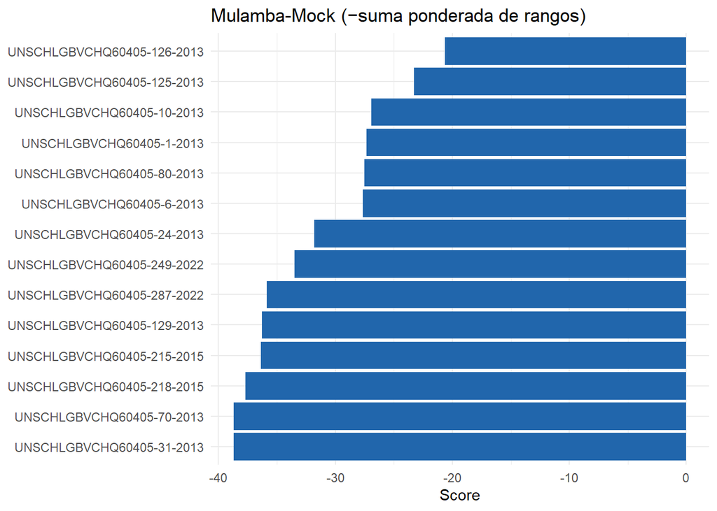

```r
rmat <- apply(M, 2, \(x) rank(-x, ties.method = "average"))
scores$`Mulamba-Mock` <- -as.vector(rmat %*% w)

plot_top("Mulamba-Mock", "Mulamba-Mock (−suma ponderada de rangos)")
```

```r
top_df("Mulamba-Mock") |> web_table(caption = "Top 10 % accessions by Mulamba-Mock index")
```

| Rank | Accession | Score | SYP | TSW | PH | SD |
| --- | --- | --- | --- | --- | --- | --- |
| 1 | UNSCHLGBVCHQ60405-126-2013 | -20.64 | 90.81 | 3.14 | 141.07 | 16.9 |
| 2 | UNSCHLGBVCHQ60405-125-2013 | -23.29 | 54.07 | 4.05 | 160.19 | 21.55 |
| 3 | UNSCHLGBVCHQ60405-10-2013 | -26.93 | 45.64 | 3.67 | 142.31 | 12.39 |
| 4 | UNSCHLGBVCHQ60405-1-2013 | -27.36 | 49.05 | 3.49 | 115.19 | 12.74 |
| 5 | UNSCHLGBVCHQ60405-80-2013 | -27.5 | 39.38 | 3.75 | 127.13 | 13.85 |
| 6 | UNSCHLGBVCHQ60405-6-2013 | -27.64 | 34.52 | 3.79 | 138.51 | 15.71 |
| 7 | UNSCHLGBVCHQ60405-24-2013 | -31.79 | 32.76 | 3.49 | 131.91 | 15.99 |
| 8 | UNSCHLGBVCHQ60405-249-2022 | -33.5 | 37.03 | 3.32 | 135.87 | 13.04 |
| 9 | UNSCHLGBVCHQ60405-287-2022 | -35.86 | 108.87 | 2.87 | 148.86 | 13.14 |
| 10 | UNSCHLGBVCHQ60405-129-2013 | -36.29 | 61.8 | 2.94 | 150.23 | 16.03 |

[output cut: 4 more lines]

## 4.5 Distance to the ideotype

The ideotype takes the best value of every oriented trait (maximum for SYP, TSW and SD; P25–P75 range for PH). Accessions were scored by the negative weighted Euclidean distance to it.

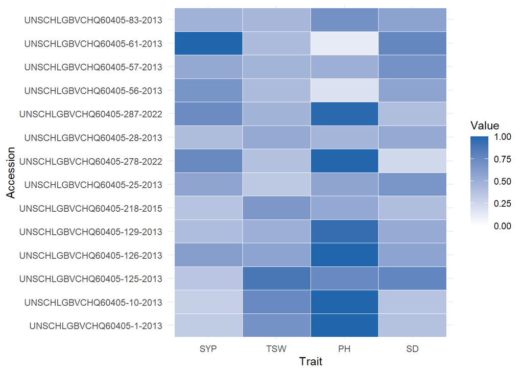

```r
scores$Ideotype <- -sqrt(rowSums(sweep((1 - as.matrix(M))^2, 2, w, "*")))

M[as.character(top_df("Ideotype")$Accession), ] |>
  tibble::rownames_to_column("Accession") |>
  tidyr::pivot_longer(-Accession, names_to = "Trait", values_to = "Value") |>
  dplyr::mutate(Trait = factor(Trait, levels = vars4)) |>
  ggplot(aes(Trait, Accession, fill = Value)) +
  geom_tile(color = "white") +
  scale_fill_gradient(low = "white", high = "#2166AC", limits = c(0, 1)) +
  theme_minimal()
```

```r
top_df("Ideotype") |> web_table(caption = "Top 10 % accessions closest to the ideotype")
```

| Rank | Accession | Score | SYP | TSW | PH | SD |
| --- | --- | --- | --- | --- | --- | --- |
| 1 | UNSCHLGBVCHQ60405-126-2013 | -0.3808 | 90.81 | 3.14 | 141.07 | 16.9 |
| 2 | UNSCHLGBVCHQ60405-287-2022 | -0.4012 | 108.87 | 2.87 | 148.86 | 13.14 |
| 3 | UNSCHLGBVCHQ60405-125-2013 | -0.4452 | 54.07 | 4.05 | 160.19 | 21.55 |
| 4 | UNSCHLGBVCHQ60405-61-2013 | -0.4618 | 146.94 | 2.72 | 191.56 | 21.32 |
| 5 | UNSCHLGBVCHQ60405-278-2022 | -0.4683 | 110.05 | 2.61 | 147.85 | 9.5 |
| 6 | UNSCHLGBVCHQ60405-57-2013 | -0.4699 | 80.78 | 2.86 | 172.77 | 19.58 |
| 7 | UNSCHLGBVCHQ60405-83-2013 | -0.4919 | 71.92 | 2.79 | 162.65 | 17.11 |
| 8 | UNSCHLGBVCHQ60405-25-2013 | -0.5014 | 83.99 | 2.47 | 169.42 | 19.06 |
| 9 | UNSCHLGBVCHQ60405-129-2013 | -0.5037 | 61.8 | 2.94 | 150.23 | 16.03 |
| 10 | UNSCHLGBVCHQ60405-56-2013 | -0.513 | 100 | 2.72 | 188.48 | 16.92 |

[output cut: 4 more lines]

## 4.6 Random forest

A random forest (2000 trees) predicted the weighted selection index (SYP, TSW and SD positive; PH penalty negative) from the four traits, with PH entered as its penalty. The out-of-bag prediction was used as the selection score, and permutation importance ranks the traits.

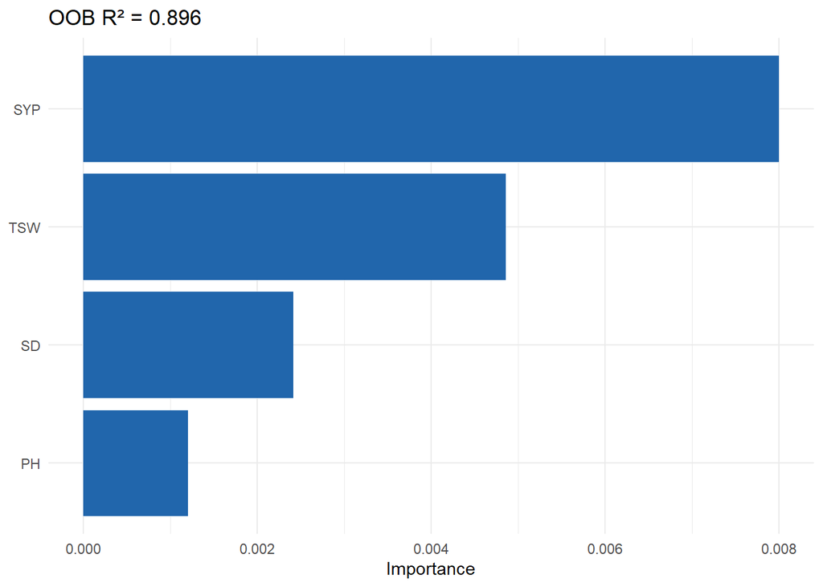

```r
set.seed(123)
rf_df <- data.frame(SYP = dat$SYP, TSW = dat$TSW, SD = dat$SD,
                    PH  = ph_pen,                                  # PH penalty
                    Index = as.numeric(as.matrix(M[, vars4]) %*% w))  # target: oriented weighted index
rf <- ranger::ranger(Index ~ ., data = rf_df, num.trees = 2000,
                     importance = "permutation", seed = 123)
scores$RF <- rf$predictions

tibble::tibble(Variable = names(rf$variable.importance),
               Importance = rf$variable.importance) |>
  ggplot(aes(reorder(Variable, Importance), Importance)) +
  geom_col(fill = "#2166AC") + coord_flip() +
  labs(x = NULL, title = paste0("OOB R² = ", round(rf$r.squared, 3))) +
  theme_minimal()
```

```r
top_df("RF") |> web_table(caption = "Top 10 % accessions by random forest (predicted index)")
```

| Rank | Accession | Score | SYP | TSW | PH | SD |
| --- | --- | --- | --- | --- | --- | --- |
| 1 | UNSCHLGBVCHQ60405-56-2013 | 0.5901 | 100 | 2.72 | 188.48 | 16.92 |
| 2 | UNSCHLGBVCHQ60405-287-2022 | 0.5544 | 108.87 | 2.87 | 148.86 | 13.14 |
| 3 | UNSCHLGBVCHQ60405-61-2013 | 0.5503 | 146.94 | 2.72 | 191.56 | 21.32 |
| 4 | UNSCHLGBVCHQ60405-126-2013 | 0.5264 | 90.81 | 3.14 | 141.07 | 16.9 |
| 5 | UNSCHLGBVCHQ60405-57-2013 | 0.5132 | 80.78 | 2.86 | 172.77 | 19.58 |
| 6 | UNSCHLGBVCHQ60405-32-2013 | 0.5124 | 71.15 | 2.88 | 187.18 | 16.7 |
| 7 | UNSCHLGBVCHQ60405-80-2013 | 0.5091 | 39.38 | 3.75 | 127.13 | 13.85 |
| 8 | UNSCHLGBVCHQ60405-6-2013 | 0.5036 | 34.52 | 3.79 | 138.51 | 15.71 |
| 9 | UNSCHLGBVCHQ60405-125-2013 | 0.5019 | 54.07 | 4.05 | 160.19 | 21.55 |
| 10 | UNSCHLGBVCHQ60405-120-2013 | 0.498 | 29.52 | 3.46 | 165.3 | 22.03 |

[output cut: 4 more lines]

## 4.7 Comparison among selection methods

Agreement among methods was assessed with Spearman and Pearson correlations, the overlap of the top 10 %, and the standardized selection differential of each trait. Accessions chosen by at least three methods are reported as consensus selections.

```r
stopifnot(all(methods %in% names(scores)),
          all(sapply(scores[methods], \(x) all(is.finite(x)))))

ranks <- scores |>
  dplyr::mutate(dplyr::across(dplyr::all_of(methods),
                              \(x) rank(-x, ties.method = "min")))

sp   <- cor(ranks[, methods], method = "spearman")
pe   <- cor(scores[, methods], method = "pearson")
tops <- lapply(methods, \(m) ranks$geno[order(ranks[[m]])][1:n_top]) |>
  setNames(methods)
ov   <- sapply(methods, \(a) sapply(methods, \(b)
                length(intersect(tops[[a]], tops[[b]]))))

sd_tab <- sapply(methods, \(m) {
  sel <- dat$geno %in% tops[[m]]
  sapply(vars4, \(v) (mean(dat[[v]][sel]) - mean(dat[[v]])) / sd(dat[[v]]))
}) |> round(2)

freq <- table(unlist(tops))
consensus <- tibble::tibble(Accession = names(freq), N_methods = as.integer(freq)) |>
  dplyr::filter(N_methods >= 3) |>
  dplyr::left_join(dat, by = c("Accession" = "geno")) |>
  dplyr::mutate(dplyr::across(dplyr::all_of(vars4), \(x) round(x, 2))) |>
  dplyr::arrange(dplyr::desc(N_methods))
```

### 4.7.1 Correlación de Spearman entre rankings

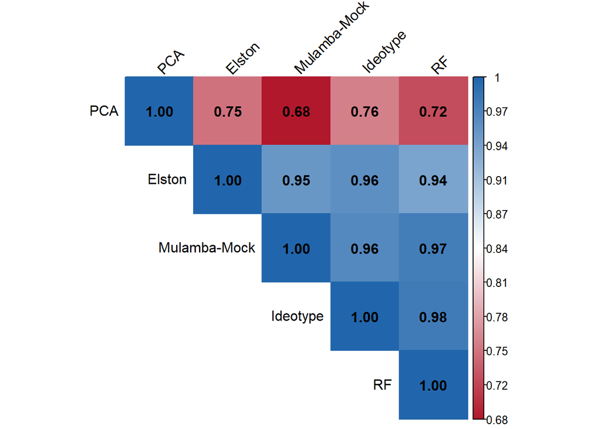

```r
corrplot::corrplot(sp, method = "color", type = "upper", addCoef.col = "black",
                   tl.col = "black", tl.srt = 45, is.corr = FALSE,
                   col = colorRampPalette(c("#B2182B", "white", "#2166AC"))(200),
                   col.lim = c(min(sp), 1))
```

### 4.7.2 Correlación de Pearson entre puntuaciones

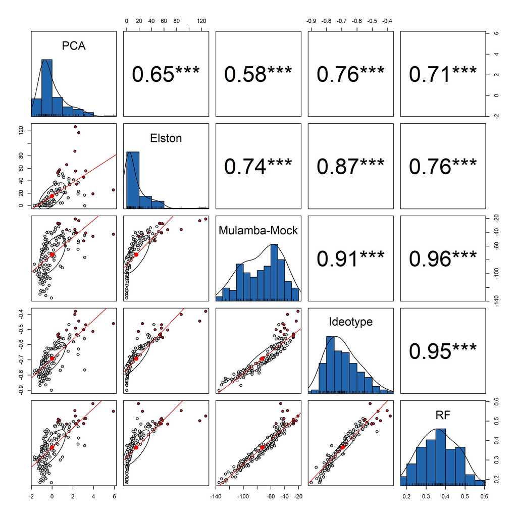

```r
sc <- as.data.frame(scores[, methods])
n_sel <- table(factor(unlist(tops), levels = scores$geno))
cons  <- as.integer(n_sel[as.character(scores$geno)]) >= 3

dir.create("files", showWarnings = FALSE)

jpeg("manuscript/Figure_5.jpg", width = 25, height = 25, units = "cm", res = 300)
psych::pairs.panels(
  sc,
  bg       = c("grey80", "#B2182B")[cons + 1],
  hist.col = "#2166AC",
  pch      = 21,
  method   = "pearson",
  stars    = TRUE,
  scale    = FALSE,
  lm       = TRUE
)
invisible(dev.off())

knitr::include_graphics("manuscript/Figure_5.jpg")
```

```r
tab_pe <- round(pe, 2) |>
  as.data.frame() |>
  tibble::rownames_to_column("Method")

tab_pe |> web_table(caption = "Pearson correlation between selection scores")
```

| Method | PCA | Elston | Mulamba-Mock | Ideotype | RF |
| --- | --- | --- | --- | --- | --- |
| PCA | 1 | 0.65 | 0.58 | 0.76 | 0.71 |
| Elston | 0.65 | 1 | 0.74 | 0.87 | 0.76 |
| Mulamba-Mock | 0.58 | 0.74 | 1 | 0.91 | 0.96 |
| Ideotype | 0.76 | 0.87 | 0.91 | 1 | 0.95 |
| RF | 0.71 | 0.76 | 0.96 | 0.95 | 1 |

### 4.7.3 Coincidencias entre las 14 accesiones seleccionadas

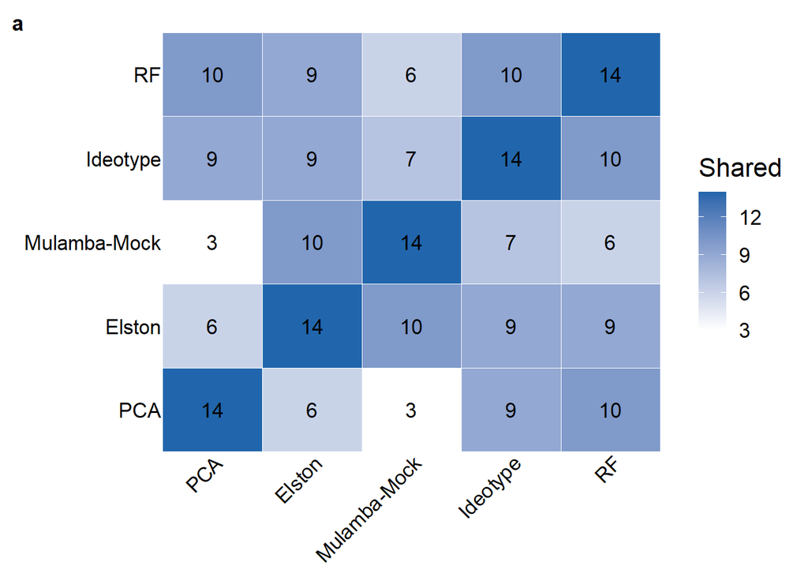

```r
library(patchwork)

# ---- Panel a: traslape top 10 % ----
p_ov <- as.data.frame(as.table(ov)) |>
  ggplot(aes(Var1, Var2, fill = Freq)) +
  geom_tile(color = "white", linewidth = 0.3) +
  geom_text(aes(label = Freq), size = 4.5) +
  scale_fill_gradient(low = "white", high = "#2166AC", name = "Shared") +
  scale_x_discrete(expand = c(0, 0)) +
  scale_y_discrete(expand = c(0, 0)) +
  labs(x = NULL, y = NULL, tag = "a") +
  theme_classic(base_size = 16) +
  theme(
    axis.line         = element_blank(),
    axis.ticks        = element_blank(),
    axis.ticks.length = unit(0, "pt"),
    axis.text.x       = element_text(angle = 45, hjust = 1, vjust = 1,
                                     margin = margin(t = 1)),
    axis.text.y       = element_text(margin = margin(r = 1)),
    panel.border      = element_blank(),
    plot.tag          = element_text(face = "bold", size = 13),
    plot.margin       = margin(8, 8, 8, 8),
    legend.position   = "right"
  )
p_ov
```

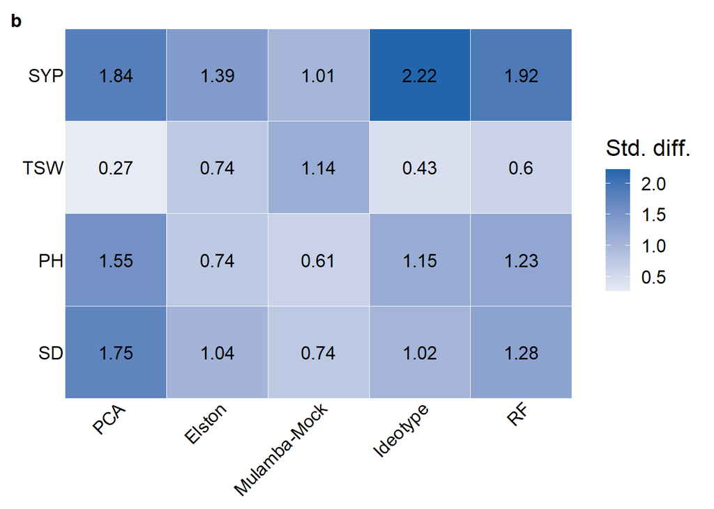

```r
# ---- Panel b: diferencial de selección ----
p_sd <- as.data.frame(as.table(sd_tab)) |>
  dplyr::mutate(Var1 = factor(Var1, levels = rev(vars4))) |>
  ggplot(aes(Var2, Var1, fill = Freq)) +
  geom_tile(color = "white", linewidth = 0.3) +
  geom_text(aes(label = round(Freq, 2)), size = 4.5) +
  scale_fill_gradient2(
    low = "#B2182B", mid = "white", high = "#2166AC",
    midpoint = 0, name = "Std. diff."
  ) +
  scale_x_discrete(expand = c(0, 0)) +
  scale_y_discrete(expand = c(0, 0)) +
  labs(x = NULL, y = NULL, tag = "b") +
  theme_classic(base_size = 16) +
  theme(
    axis.line         = element_blank(),
    axis.ticks        = element_blank(),
    axis.ticks.length = unit(0, "pt"),
    axis.text.x       = element_text(angle = 45, hjust = 1, vjust = 1,
                                     margin = margin(t = 1)),
    axis.text.y       = element_text(margin = margin(r = 1)),
    panel.border      = element_blank(),
    plot.tag          = element_text(face = "bold", size = 13),
    plot.margin       = margin(8, 8, 8, 8),
    legend.position   = "right"
  )
p_sd
```

```r
p_final <- p_ov + p_sd +
  plot_layout(ncol = 2, widths = c(1, 1), heights = c(1, 1))


ggsave(
  filename = "manuscript/Figure_4.jpg",
  plot     = p_final,
  width    = 20,
  height   = 15,
  units    = "in",
  dpi      = 600,
  bg       = "white"
)

img <- magick::image_read("manuscript/Figure_4.jpg")
img <- magick::image_trim(img)
magick::image_write(img, "manuscript/Figure_4.jpg", quality = 100)
```

## 4.8 Top 10 % accessions of all methods

```r
tab_top <- purrr::map(methods, \(m) as.character(top_df(m)$Accession)) |>
  setNames(methods) |>
  tibble::as_tibble() |>
  tibble::add_column(Rank = seq_len(n_top), .before = 1)

tab_top |> web_table(caption = "Top 10 % accessions by selection method (rank order)")
```

| Rank | PCA | Elston | Mulamba-Mock | Ideotype | RF |
| --- | --- | --- | --- | --- | --- |
| 1 | UNSCHLGBVCHQ60405-61-2013 | UNSCHLGBVCHQ60405-126-2013 | UNSCHLGBVCHQ60405-126-2013 | UNSCHLGBVCHQ60405-126-2013 | UNSCHLGBVCHQ60405-56-2013 |
| 2 | UNSCHLGBVCHQ60405-56-2013 | UNSCHLGBVCHQ60405-125-2013 | UNSCHLGBVCHQ60405-125-2013 | UNSCHLGBVCHQ60405-287-2022 | UNSCHLGBVCHQ60405-287-2022 |
| 3 | UNSCHLGBVCHQ60405-57-2013 | UNSCHLGBVCHQ60405-287-2022 | UNSCHLGBVCHQ60405-10-2013 | UNSCHLGBVCHQ60405-125-2013 | UNSCHLGBVCHQ60405-61-2013 |
| 4 | UNSCHLGBVCHQ60405-281-2022 | UNSCHLGBVCHQ60405-129-2013 | UNSCHLGBVCHQ60405-1-2013 | UNSCHLGBVCHQ60405-61-2013 | UNSCHLGBVCHQ60405-126-2013 |
| 5 | UNSCHLGBVCHQ60405-32-2013 | UNSCHLGBVCHQ60405-6-2013 | UNSCHLGBVCHQ60405-80-2013 | UNSCHLGBVCHQ60405-278-2022 | UNSCHLGBVCHQ60405-57-2013 |
| 6 | UNSCHLGBVCHQ60405-25-2013 | UNSCHLGBVCHQ60405-57-2013 | UNSCHLGBVCHQ60405-6-2013 | UNSCHLGBVCHQ60405-57-2013 | UNSCHLGBVCHQ60405-32-2013 |
| 7 | UNSCHLGBVCHQ60405-125-2013 | UNSCHLGBVCHQ60405-83-2013 | UNSCHLGBVCHQ60405-24-2013 | UNSCHLGBVCHQ60405-83-2013 | UNSCHLGBVCHQ60405-80-2013 |
| 8 | UNSCHLGBVCHQ60405-282-2022 | UNSCHLGBVCHQ60405-80-2013 | UNSCHLGBVCHQ60405-249-2022 | UNSCHLGBVCHQ60405-25-2013 | UNSCHLGBVCHQ60405-6-2013 |
| 9 | UNSCHLGBVCHQ60405-72-2013 | UNSCHLGBVCHQ60405-1-2013 | UNSCHLGBVCHQ60405-287-2022 | UNSCHLGBVCHQ60405-129-2013 | UNSCHLGBVCHQ60405-125-2013 |
| 10 | UNSCHLGBVCHQ60405-293B-2022 | UNSCHLGBVCHQ60405-10-2013 | UNSCHLGBVCHQ60405-129-2013 | UNSCHLGBVCHQ60405-56-2013 | UNSCHLGBVCHQ60405-120-2013 |

[output cut: 4 more lines]

```r
acc     <- sort(unique(as.character(unlist(tops))))
sel_mat <- sapply(methods, \(m) acc %in% as.character(tops[[m]]))

mean_rk <- ranks |>
  dplyr::transmute(Accession = as.character(geno),
                   mean_rank = rowMeans(dplyr::across(dplyr::all_of(methods))))

ticks <- tibble::tibble(Accession = acc) |>
  dplyr::bind_cols(tibble::as_tibble(ifelse(sel_mat, "✓", "")))

tab_union <- tibble::tibble(Accession = acc, N_methods = rowSums(sel_mat)) |>
  dplyr::left_join(mean_rk, by = "Accession") |>
  dplyr::left_join(ticks,   by = "Accession") |>
  dplyr::left_join(dplyr::mutate(dat, geno = as.character(geno)),
                   by = c("Accession" = "geno")) |>
  dplyr::mutate(dplyr::across(dplyr::all_of(vars4), \(x) round(x, 2))) |>
  dplyr::arrange(dplyr::desc(N_methods), mean_rank)

tab_union |> web_table(caption = "Accessions in the top 10 % of at least one method")
```

| Accession | N_methods | mean_rank | PCA | Elston | Mulamba-Mock | Ideotype | RF | SYP | TSW | PH | SD |
| --- | --- | --- | --- | --- | --- | --- | --- | --- | --- | --- | --- |
| UNSCHLGBVCHQ60405-126-2013 | 5 | 4 | ✓ | ✓ | ✓ | ✓ | ✓ | 90.81 | 3.14 | 141.07 | 16.9 |
| UNSCHLGBVCHQ60405-125-2013 | 5 | 4.6 | ✓ | ✓ | ✓ | ✓ | ✓ | 54.07 | 4.05 | 160.19 | 21.55 |
| UNSCHLGBVCHQ60405-287-2022 | 5 | 6 | ✓ | ✓ | ✓ | ✓ | ✓ | 108.87 | 2.87 | 148.86 | 13.14 |
| UNSCHLGBVCHQ60405-57-2013 | 4 | 8 | ✓ | ✓ |  | ✓ | ✓ | 80.78 | 2.86 | 172.77 | 19.58 |
| UNSCHLGBVCHQ60405-83-2013 | 4 | 11 | ✓ | ✓ |  | ✓ | ✓ | 71.92 | 2.79 | 162.65 | 17.11 |
| UNSCHLGBVCHQ60405-10-2013 | 4 | 15.4 |  | ✓ | ✓ | ✓ | ✓ | 45.64 | 3.67 | 142.31 | 12.39 |
| UNSCHLGBVCHQ60405-25-2013 | 4 | 15.8 | ✓ | ✓ |  | ✓ | ✓ | 83.99 | 2.47 | 169.42 | 19.06 |
| UNSCHLGBVCHQ60405-61-2013 | 3 | 12.2 | ✓ |  |  | ✓ | ✓ | 146.94 | 2.72 | 191.56 | 21.32 |
| UNSCHLGBVCHQ60405-129-2013 | 3 | 12.4 |  | ✓ | ✓ | ✓ |  | 61.8 | 2.94 | 150.23 | 16.03 |
| UNSCHLGBVCHQ60405-6-2013 | 3 | 13.6 |  | ✓ | ✓ |  | ✓ | 34.52 | 3.79 | 138.51 | 15.71 |

[output cut: 18 more lines]

```r
vars_imp <- c("PCC", "PD", "GH", "PS")
lab_imp  <- c(PCC = "Grain (pericarp) color", PD = "Panicle density",
              GH = "Growth habit", PS = "Panicle shape")

top14 <- tab_union |>
  dplyr::slice_head(n = n_top)

quali_cod <- quali |>
  dplyr::mutate(Trat = as.character(geno)) |>
  dplyr::left_join(
    dplyr::mutate(passport_data, Trat = as.character(Trat)) |>
      dplyr::select(Trat, CODIGO),
    by = "Trat") |>
  dplyr::transmute(Accession = as.character(CODIGO),
                   dplyr::across(dplyr::all_of(vars_imp), as.character)) |>
  dplyr::distinct(Accession, .keep_all = TRUE)

tab_quali <- top14 |>
  dplyr::select(Accession, N_methods, dplyr::all_of(vars4)) |>
  dplyr::left_join(quali_cod, by = "Accession")

# Verificaciones
stopifnot(nrow(tab_quali) == 14)
stopifnot(identical(tab_quali$Accession, top14$Accession))
if (anyNA(tab_quali[vars_imp])) {
  warning("Accesiones sin dato cualitativo: ",
          paste(tab_quali$Accession[!complete.cases(tab_quali[vars_imp])],
                collapse = ", "))
}

dir.create("files", showWarnings = FALSE)
tab_quali |> web_table(caption = "Top 14 accessions: quantitative and key qualitative traits")
```

| Accession | N_methods | SYP | TSW | PH | SD | PCC | PD | GH | PS |
| --- | --- | --- | --- | --- | --- | --- | --- | --- | --- |
| UNSCHLGBVCHQ60405-126-2013 | 5 | 90.81 | 3.14 | 141.07 | 16.9 | Cream | Compact | Simple | Glomerulate |
| UNSCHLGBVCHQ60405-125-2013 | 5 | 54.07 | 4.05 | 160.19 | 21.55 | Golden yellow | Compact | Simple | Glomerulate |
| UNSCHLGBVCHQ60405-287-2022 | 5 | 108.87 | 2.87 | 148.86 | 13.14 | Light brown | Intermediate | Branched to the second third | Glomerulate |
| UNSCHLGBVCHQ60405-57-2013 | 4 | 80.78 | 2.86 | 172.77 | 19.58 | Cream | Lax | Simple | Glomerulate |
| UNSCHLGBVCHQ60405-83-2013 | 4 | 71.92 | 2.79 | 162.65 | 17.11 | Golden yellow | Intermediate | Simple | Glomerulate |
| UNSCHLGBVCHQ60405-10-2013 | 4 | 45.64 | 3.67 | 142.31 | 12.39 | Golden yellow | Lax | Branched to the second third | Glomerulate |
| UNSCHLGBVCHQ60405-25-2013 | 4 | 83.99 | 2.47 | 169.42 | 19.06 | Cream | Intermediate | Branched with undefined main panicle | Amaranthiform |
| UNSCHLGBVCHQ60405-61-2013 | 3 | 146.94 | 2.72 | 191.56 | 21.32 | Golden yellow | Compact | Simple | Amaranthiform |
| UNSCHLGBVCHQ60405-129-2013 | 3 | 61.8 | 2.94 | 150.23 | 16.03 | Cream | Lax | Simple | Glomerulate |
| UNSCHLGBVCHQ60405-6-2013 | 3 | 34.52 | 3.79 | 138.51 | 15.71 | Golden yellow | Intermediate | Simple | Glomerulate |

[output cut: 4 more lines]

```r
writexl::write_xlsx(list(Quant_Quali = tab_quali), "files/Table-selected.xlsx")
```

```r
table3 <- top14 |>
  dplyr::select(Accession, N = N_methods,
                dplyr::all_of(methods), dplyr::all_of(vars4)) |>
  dplyr::mutate(Accession = sub("UNSCHLGBVCHQ60405", "UNSCH", Accession))

table3 |> web_table(caption = "Table 3")
```

| Accession | N | PCA | Elston | Mulamba-Mock | Ideotype | RF | SYP | TSW | PH | SD |
| --- | --- | --- | --- | --- | --- | --- | --- | --- | --- | --- |
| UNSCH-126-2013 | 5 | ✓ | ✓ | ✓ | ✓ | ✓ | 90.81 | 3.14 | 141.07 | 16.9 |
| UNSCH-125-2013 | 5 | ✓ | ✓ | ✓ | ✓ | ✓ | 54.07 | 4.05 | 160.19 | 21.55 |
| UNSCH-287-2022 | 5 | ✓ | ✓ | ✓ | ✓ | ✓ | 108.87 | 2.87 | 148.86 | 13.14 |
| UNSCH-57-2013 | 4 | ✓ | ✓ |  | ✓ | ✓ | 80.78 | 2.86 | 172.77 | 19.58 |
| UNSCH-83-2013 | 4 | ✓ | ✓ |  | ✓ | ✓ | 71.92 | 2.79 | 162.65 | 17.11 |
| UNSCH-10-2013 | 4 |  | ✓ | ✓ | ✓ | ✓ | 45.64 | 3.67 | 142.31 | 12.39 |
| UNSCH-25-2013 | 4 | ✓ | ✓ |  | ✓ | ✓ | 83.99 | 2.47 | 169.42 | 19.06 |
| UNSCH-61-2013 | 3 | ✓ |  |  | ✓ | ✓ | 146.94 | 2.72 | 191.56 | 21.32 |
| UNSCH-129-2013 | 3 |  | ✓ | ✓ | ✓ |  | 61.8 | 2.94 | 150.23 | 16.03 |
| UNSCH-6-2013 | 3 |  | ✓ | ✓ |  | ✓ | 34.52 | 3.79 | 138.51 | 15.71 |

[output cut: 4 more lines]

```r
writexl::write_xlsx(list(Table3 = table3), "files/Table-3-manuscript.xlsx")
```

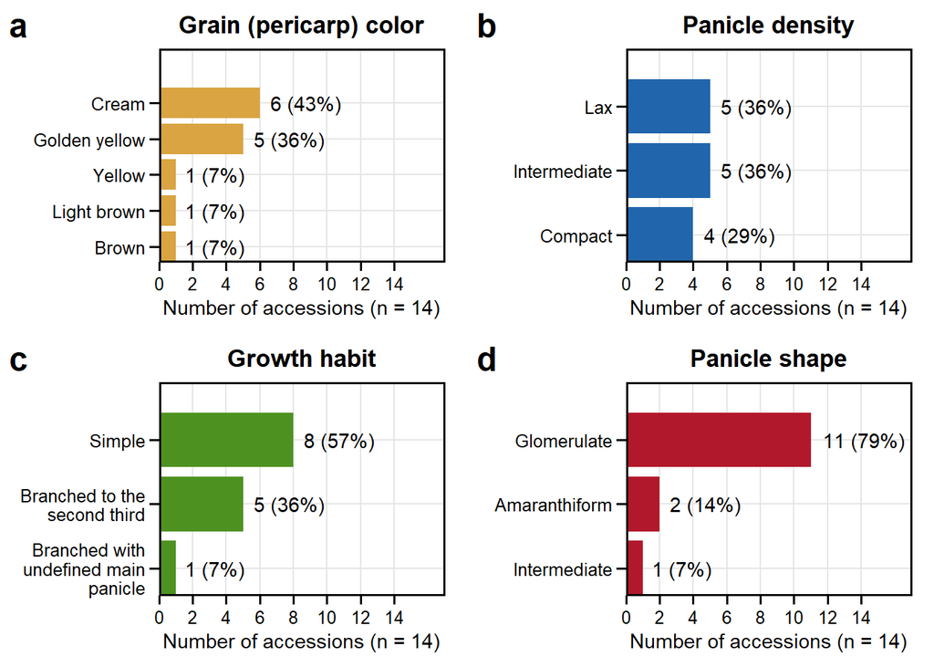

Figure 1

```r
pal <- c(PCC = "#D9A441", PD = "#2166AC", GH = "#4D9221", PS = "#B2182B")

mk_panel <- function(v) {
  d <- tab_quali |>
    dplyr::count(Class = .data[[v]]) |>
    dplyr::filter(!is.na(Class)) |>
    dplyr::mutate(Class = reorder(Class, n),
                  lab   = sprintf("%d (%.0f%%)", n, n / 14 * 100))

  ggplot(d, aes(n, Class)) +
    geom_col(fill = pal[[v]], width = 0.85) +
    geom_text(aes(label = lab), hjust = -0.15, size = 3.8) +
    scale_y_discrete(expand = expansion(add = c(0, 0.30 * nrow(d))),
                     labels = \(x) stringr::str_wrap(x, 20)) +
    scale_x_continuous(expand = c(0, 0), limits = c(0, 17), breaks = seq(0, 14, 2)) +
    labs(title = lab_imp[[v]], x = "Number of accessions (n = 14)", y = NULL) +
    theme_bw(base_size = 12) +
    theme(plot.title        = element_text(face = "bold", hjust = 0.5, size = 13),
          panel.border      = element_rect(color = "black", fill = NA, linewidth = 0.9),
          panel.grid.major  = element_line(color = "grey90", linewidth = 0.4),
          panel.grid.minor  = element_blank(),
          axis.ticks        = element_line(color = "black"),
          axis.ticks.length = unit(0.18, "cm"),
          axis.text         = element_text(color = "black"),
          axis.title        = element_text(size = 11),
          plot.margin       = margin(8, 12, 8, 8))
}

p_prof <- cowplot::plot_grid(
  plotlist = lapply(vars_imp, mk_panel),
  labels = c("a", "b", "c", "d"), label_size = 18, label_fontface = "bold",
  ncol = 2, align = "hv", axis = "tblr"
)

p_prof
ggsave("files/Figure_1.jpg", p_prof, width = 11, height = 7.5,
       units = "in", dpi = 600, bg = "white")
```

```r
## Supplementary Excel
dir.create("manuscript", showWarnings = FALSE)

sheets <- c(
  list(Scores        = scores,
       Ranks         = ranks,
       Spearman      = tibble::as_tibble(round(sp, 2), rownames = "Method"),
       Pearson       = tab_pe,
       Top10_overlap = tibble::as_tibble(ov, rownames = "Method"),
       Std_sel_diff  = tibble::as_tibble(sd_tab, rownames = "Trait"),
       Top10_wide    = tab_top,
       Top10_union   = tab_union,
       Top14_Table3  = table3,
       Top14_Quali   = tab_quali,
       Consensus     = consensus),
  setNames(lapply(methods, top_df), paste0("Top_", gsub("-", "_", methods)))
)

writexl::write_xlsx(sheets, "files/Table-3.xlsx")
```

# 5 Final table

Qualitative descriptors (28, acronyms as column names) and quantitative BLUEs (13) for the 144 accessions.

```r
quali_fin <- quali |>
  dplyr::mutate(geno = as.character(geno)) |>
  dplyr::left_join(
    passport_data |>
      dplyr::mutate(Trat = as.character(Trat)) |>
      dplyr::select(Trat, CODIGO),
    by = c("geno" = "Trat")
  ) |>
  dplyr::mutate(geno = CODIGO) |>
  dplyr::select(-CODIGO)

blues_fin <- blues |>
  dplyr::mutate(
    geno = as.character(geno),
    dplyr::across(-geno, ~ ifelse(.x < 0, 0, .x)),
    dplyr::across(-geno, ~ round(.x, 2))
  )

# passport data (one row per accession, English headers)
pass_fin <- passport_data |>
  dplyr::transmute(
    Accession        = as.character(CODIGO),
    `Collection date` = as.character(`Fecha de colección`),
    Country          = as.character(`País`),
    Department       = as.character(Departamento),
    Province         = as.character(Provincia),
    District         = as.character(Distrito),
    Locality         = as.character(Localidad),
    `Altitude (masl)` = `Altitud (msnm)`
  ) |>
  dplyr::distinct(Accession, .keep_all = TRUE)

final_tab <- quali_fin |>
  dplyr::left_join(blues_fin, by = "geno") |>
  dplyr::rename(Accession = geno) |>
  dplyr::left_join(pass_fin, by = "Accession") |>
  dplyr::relocate(names(pass_fin)[-1], .after = Accession)

n_quali  <- ncol(quali_fin) - 1
n_quanti <- ncol(blues_fin) - 1
n_pass   <- ncol(pass_fin) - 1

stopifnot(
  nrow(final_tab) == 144,
  !anyNA(final_tab$Accession),
  !anyDuplicated(final_tab$Accession),
  n_quali  == 28,
  n_quanti == 13,
  n_pass   == 7,
  ncol(final_tab) == 1 + 7 + 28 + 13,
  !"PHS" %in% names(final_tab)
)

final_tab |> web_table(caption = "Final table: passport data, qualitative descriptors and quantitative BLUEs (144 accessions)")
```

| Accession | Collection date | Country | Department | Province | District | Locality | Altitude (masl) | PLD | GT | GH | SMS | MSC | PPA | PST | STC | PB | PPB | LS | LM | PC | LLC | LGC | MST | PCF | PCPM | PS | PD | DH | PA | … |
| --- | --- | --- | --- | --- | --- | --- | --- | --- | --- | --- | --- | --- | --- | --- | --- | --- | --- | --- | --- | --- | --- | --- | --- | --- | --- | --- | --- | --- | --- | --- |
| UNSCHLGBVCHQ60405-1-2013 | 2013 | Perú | Ayacucho | Sucre | Chalcos | Ayalca | 3649 | Sparse | Herbaceous | Branched to the second third | Angular | Purple | Present | Present | Green | Absent | Emerge obliquely from main stem | Rhomboid | Toothed | Green | Green-Red (striated/variegated) | Absent | Absent (stigma overgrowth) | Purple | Orange | Intermediate | Compact | Slight | Semi-open | … |
| UNSCHLGBVCHQ60405-296-2023 | 2013 | Perú | Ayacucho | Lucanas | Chaviña | Chaviña | 3210 | Intermediate | Shrubby | Simple | Cylindrical | White | Present | Present | Green | Absent | Emerge from the base with some curvature | Triangular | Toothed | Green | Green | Purple | Present (anthers absent) | Mixture (purple and red) | Red and pink | Glomerulate | Intermediate | Moderate | Closed | … |
| UNSCHLGBVCHQ60405-228-2015 | 2015 | Perú | Ayacucho | Huamanga | Huamanga | LGBV-UNSCH | 2760 | Intermediate | Herbaceous | Branched to the second third | Angular | Yellow | Present | Present | Green | Absent | Emerge obliquely from main stem | Triangular | Toothed | Green | Green | White | Present (anthers absent) | Green | Red and white | Amaranthiform | Compact | Slight | Semi-open | … |
| UNSCHLGBVCHQ60405-230-2015 | 2015 | Perú | Ayacucho | Huamanga | Huamanga | LGBV-UNSCH | 2760 | Intermediate | Herbaceous | Simple | Cylindrical | Orange | Present | Present | Purple | Present | Emerge obliquely from main stem | Rhomboid | Entire | Green | Green | Purple | Present (anthers absent) | Purple | Brown | Amaranthiform | Compact | Slight | Semi-open | … |
| UNSCHLGBVCHQ60405-231-2015 | 2015 | Perú | Ayacucho | Huamanga | Huamanga | LGBV-UNSCH | 2760 | Sparse | Herbaceous | Simple | Angular | Yellow | Absent | Present | Green | Absent | Emerge obliquely from main stem | Rhomboid | Toothed | Green | Green | White | Present (anthers absent) | Green | Brown | Glomerulate | Lax | Moderate | Semi-open | … |
| UNSCHLGBVCHQ60405-232-2015 | 2015 | Perú | Ayacucho | Huamanga | Huamanga | LGBV-UNSCH | 2760 | High | Herbaceous | Simple | Cylindrical | Yellow | Present | Present | Green | Absent | Emerge obliquely from main stem | Triangular | Toothed | Green | Green | Absent | Present (anthers absent) | Green | Yellow | Amaranthiform | Intermediate | Strong | Semi-open | … |
| UNSCHLGBVCHQ60405-233-2015 | 2015 | Perú | Ayacucho | Huamanga | Huamanga | LGBV-UNSCH | 2760 | High | Herbaceous | Simple | Cylindrical | Yellow | Present | Present | Green | Absent | Emerge obliquely from main stem | Triangular | Toothed | Green | Green | Absent | Present (anthers absent) | Green | Yellow | Glomerulate | Intermediate | Slight | Semi-open | … |
| UNSCHLGBVCHQ60405-234-2015 | 2015 | Perú | Ayacucho | Huamanga | Huamanga | LGBV-UNSCH | 2760 | High | Shrubby | Simple | Angular | Yellow | Present | Present | Green | Absent | Emerge obliquely from main stem | Triangular | Toothed | Green | Green | Absent | Present (anthers absent) | Green | Yellow | Glomerulate | Intermediate | Slight | Closed | … |
| UNSCHLGBVCHQ60405-238-2022 | 2022 | Perú | Ayacucho | Huamanga | Andres Avelino Caceres | CEE-CANAÁN-INIA | 2760 | High | Shrubby | Simple | Cylindrical | Yellow | Present | Present | Purple | Absent | Emerge obliquely from main stem | Triangular | Toothed | Green | Green | Absent | Present (anthers absent) | Green | Yellow | Amaranthiform | Intermediate | Moderate | Semi-open | … |
| UNSCHLGBVCHQ60405-239-2022 | 2022 | Perú | Ayacucho | La mar | San Miguel | San Miguel | 2661 | High | Shrubby | Simple | Cylindrical | Yellow | Present | Present | Green | Absent | Emerge obliquely from main stem | Triangular | Toothed | Green | Green | Absent | Present (anthers absent) | Green | Yellow | Amaranthiform | Intermediate | Moderate | Semi-open | … |

[output cut: 134 more lines]

```r
writexl::write_xlsx(final_tab, "files/Final-table.xlsx")
```

# 6 END